# Customer Status Prediction

Bartu Paçal, Begüm Başovalı

2025-12-29

# Customer Status Prediction: Training Walkthrough

## 0) Setup

- Clear the workspace to avoid stale objects, fix a seed for reproducibility, and define project/data paths.
- Load the packages used across EDA, preprocessing, and modeling.

```r
rm(list = ls())
set.seed(42)

PROJECT_DIR <- "C:/Users/Bartu/Desktop/Customer_Status_Prediction"
DATA_DIR <- file.path(PROJECT_DIR, "Train Datasets")

library(dplyr)
library(tidyr)
library(caret)
library(corrplot)
library(ggplot2)
library(randomForest)
library(nnet)
library(gbm)
library(psych)
library(scales)
library(pROC)
library(tidytext)
```

## 1) Read Data

- Set up a helper to load CSVs from `DATA_DIR` and keep column types as character/numeric (no automatic factors).
- List all train files in one place so it’s easy to add/remove sources.
- Load into a named list, then unpack into the global environment for downstream steps.

```r
cat("\nReading data files...\n")
```

```
##
## Reading data files...
```

```r
read_data_file <- function(file_name) {
  read.csv(file.path(DATA_DIR, file_name), stringsAsFactors = FALSE)
}

data_files <- list(
  status = "customer_status_level_train.csv",
  demographics = "customer_demographics_train.csv",
  revenue = "customer_monthly_recurring_revenue_train.csv",
  region = "customer_region_and_industry_train.csv",
  history = "customer_revenue_history_train.csv",
  satisfaction = "customer_satisfaction_scores_train.csv",
  engagement = "newsletter_engagement_train.csv",
  bug = "product_bug_reports_train.csv",
  ticket = "support_ticket_activity_train.csv"
)

data_list <- lapply(data_files, read_data_file)
names(data_list) <- c(
  "Customer_Status", "Customer_Demographics", "Customer_Revenue",
  "Customer_Region_Industry", "Customer_Revenue_History",
  "Customer_Satisfaction", "Customer_Engagement",
  "Customer_Bug_Reports", "Customer_Ticket_Activity"
)

list2env(data_list, envir = .GlobalEnv)
```

```
## <environment: R_GlobalEnv>
```

```r
cat("Data files loaded.\n")
```

```
## Data files loaded.
```

## 2) Standardize ID Column Names

- Align key columns to a single `Customer.ID` naming so joins/merges stay consistent across tables.
- Rename once up front to avoid scattered fixes later.

```r
Customer_Demographics <- Customer_Demographics %>%
  rename(Customer.ID = CUS.ID)
```

## 3) Duplicate Record Check

- Build a quick audit table: row/column counts, NA totals, and unique customer counts per table.
- Inspect per-column types, NA rates, and cardinality to spot bad or sparse fields.
- Review target balance, then count duplicate IDs per dataset.

```r
cat("\nDuplicate record check...\n")
```

```
##
## Duplicate record check...
```

```r
cat("\nStarting data set preliminary examination...\n")
```

```
##
## Starting data set preliminary examination...
```

```r
data_summary <- data.frame(
  Dataset = names(data_list),
  Rows = sapply(data_list, nrow),
  Cols = sapply(data_list, ncol),
  Total_NA = sapply(data_list, function(x) sum(is.na(x))),
  Unique_Customers = sapply(data_list, function(x) {
    id_col <- grep("ID", names(x), value = TRUE, ignore.case = TRUE)[1]
    if (!is.na(id_col)) length(unique(x[[id_col]])) else NA
  })
)

print(data_summary)
```

```
##                                           Dataset Rows Cols Total_NA
## Customer_Status                   Customer_Status 2068    3        0
## Customer_Demographics       Customer_Demographics 2068    2        0
## Customer_Revenue                 Customer_Revenue 1056    2        0
## Customer_Region_Industry Customer_Region_Industry 2068    4        0
## Customer_Revenue_History Customer_Revenue_History  712    2        0
## Customer_Satisfaction       Customer_Satisfaction 1571   11       47
## Customer_Engagement           Customer_Engagement  199    2        0
## Customer_Bug_Reports         Customer_Bug_Reports 1571    2        0
## Customer_Ticket_Activity Customer_Ticket_Activity 1072    3        0
##                          Unique_Customers
## Customer_Status                      2068
## Customer_Demographics                2068
## Customer_Revenue                     1056
## Customer_Region_Industry             2068
## Customer_Revenue_History              712
## Customer_Satisfaction                 502
## Customer_Engagement                   199
## Customer_Bug_Reports                  502
## Customer_Ticket_Activity             1072
```

```r
cat("\nDetailed column and type analysis:\n")
```

```
##
## Detailed column and type analysis:
```

```r
check_details <- function(df_name, df) {
  cat(paste0("\n--- Table: ", df_name, " ---\n"))
  details <- data.frame(
    Column = names(df),
    Type = sapply(df, class),
    NA_Count = sapply(df, function(x) sum(is.na(x))),
    NA_Perc = sapply(df, function(x) round(mean(is.na(x)) * 100, 2)),
    Unique_Values = sapply(df, function(x) length(unique(x)))
  )
  print(details)
}

invisible(lapply(names(data_list), function(n) check_details(n, data_list[[n]])))
```

```
##
## --- Table: Customer_Status ---
##                        Column      Type NA_Count NA_Perc Unique_Values
## Customer.ID       Customer.ID character        0       0          2068
## Status                 Status character        0       0             3
## Customer.Level Customer.Level character        0       0             4
##
## --- Table: Customer_Demographics ---
##                                      Column      Type NA_Count NA_Perc
## CUS.ID                               CUS.ID character        0       0
## Customer.Age..Months. Customer.Age..Months.   integer        0       0
##                       Unique_Values
## CUS.ID                         2068
## Customer.Age..Months.            72
##
## --- Table: Customer_Revenue ---
##                  Column      Type NA_Count NA_Perc Unique_Values
## Customer.ID Customer.ID character        0       0          1056
## MRR                 MRR character        0       0           795
##
## --- Table: Customer_Region_Industry ---
##                  Column      Type NA_Count NA_Perc Unique_Values
## Customer.ID Customer.ID character        0       0          2068
## Region           Region character        0       0            24
## Vertical       Vertical character        0       0            23
## Subvertical Subvertical character        0       0            51
##
## --- Table: Customer_Revenue_History ---
##                      Column      Type NA_Count NA_Perc Unique_Values
## Customer.ID     Customer.ID character        0       0           712
## Total.Revenue Total.Revenue character        0       0           570
##
## --- Table: Customer_Satisfaction ---
##                                                                                                                                              Column
## Customer.ID                                                                                                                             Customer.ID
## Year                                                                                                                                           Year
## Quarter                                                                                                                                     Quarter
## Survey.Date                                                                                                                             Survey.Date
## Response.Date                                                                                                                         Response.Date
## How.likely.are.you.to.recommend.insider.to.a.friend.or.colleague                   How.likely.are.you.to.recommend.insider.to.a.friend.or.colleague
```

[output cut: 64 more lines]

```
## Customer.ID                       Customer.ID character        0       0
## Product.Bug.Task.Count Product.Bug.Task.Count   integer        0       0
##                        Unique_Values
## Customer.ID                      502
## Product.Bug.Task.Count           161
##
## --- Table: Customer_Ticket_Activity ---
##                                                      Column      Type NA_Count
## Customer.ID                                     Customer.ID character        0
## Help.Ticket.Count                         Help.Ticket.Count   integer        0
## Help.Ticket.Lead.Time..hours. Help.Ticket.Lead.Time..hours.   integer        0
##                               NA_Perc Unique_Values
## Customer.ID                         0          1072
## Help.Ticket.Count                   0            94
## Help.Ticket.Lead.Time..hours.       0           767
```

```r
cat("\nTarget variable distribution:\n")
```

```
##
## Target variable distribution:
```

```r
status_dist <- table(Customer_Status$Status)
print(status_dist)
```

```
##
##      Churn Onboarding   Retained
##        972        256        840
```

```r
print(prop.table(status_dist))
```

```
##
##      Churn Onboarding   Retained
##  0.4700193  0.1237911  0.4061896
```

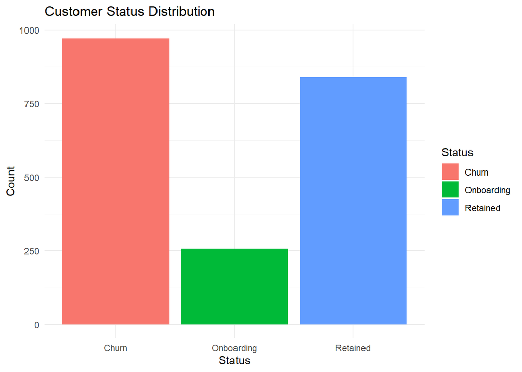

```r
ggplot(Customer_Status, aes(x = Status, fill = Status)) +
  geom_bar() +
  theme_minimal() +
  labs(title = "Customer Status Distribution", x = "Status", y = "Count")
```

```r
dup_counts <- sapply(data_list, function(x) {
  id_col <- grep("ID", names(x), value = TRUE, ignore.case = TRUE)[1]
  if (!is.na(id_col)) sum(duplicated(x[[id_col]])) else 0
})

dup_summary <- data.frame(
  Dataset = names(dup_counts),
  Duplicate_IDs = as.numeric(dup_counts)
)

cat("\nDuplicate ID counts:\n")
```

```
##
## Duplicate ID counts:
```

```r
print(dup_summary)
```

```
##                    Dataset Duplicate_IDs
## 1          Customer_Status             0
## 2    Customer_Demographics             0
## 3         Customer_Revenue             0
## 4 Customer_Region_Industry             0
## 5 Customer_Revenue_History             0
## 6    Customer_Satisfaction          1069
## 7      Customer_Engagement             0
## 8     Customer_Bug_Reports          1069
## 9 Customer_Ticket_Activity             0
```

## 4) Aggregation - Customer-based Summarization

- Müşteri bazında özetler: kategorikler için mod, sayımlar için toplam, sürekli skorlar için ortalama.
- Son memnuniyet anketinin tarih/çeyrek bilgisini de sakla.
- Tekrarlı satır yoksa ilgili tabloları olduğu gibi bırak.

```r
cat("\nData aggregation operations...\n")
```

```
##
## Data aggregation operations...
```

```r
get_mode_chr <- function(x) {
  x <- x[!is.na(x)]
  if (length(x) == 0) return(NA_character_)
  tb <- sort(table(x), decreasing = TRUE)
  names(tb)[1]
}

Customer_Bug_Reports_Agg <- Customer_Bug_Reports %>%
  group_by(Customer.ID) %>%
  summarise(
    Total_Bug_Count = sum(Product.Bug.Task.Count, na.rm = TRUE),
    .groups = "drop"
  )

names(Customer_Satisfaction) <- c(
  "Customer.ID", "Year", "Quarter", "Survey_Date", "Response_Date",
  "NPS", "Value_Score", "Usage_Freq", "Quality_Score",
  "Usability_Score", "Reporting_Score"
)

Customer_Satisfaction <- Customer_Satisfaction %>%
  mutate(
    Survey_Date = as.Date(Survey_Date),
    Response_Date = as.Date(Response_Date)
  )

last_rows <- Customer_Satisfaction %>%
  mutate(last_date = coalesce(Survey_Date, Response_Date)) %>%
  arrange(Customer.ID, last_date) %>%
  group_by(Customer.ID) %>%
  slice_tail(n = 1) %>%
  ungroup() %>%
  select(Customer.ID, Year, Quarter, Survey_Date, Response_Date)

Customer_Satisfaction_Agg <- Customer_Satisfaction %>%
  group_by(Customer.ID) %>%
  summarise(
    NPS_mean = mean(NPS, na.rm = TRUE),
    Value_mean = mean(Value_Score, na.rm = TRUE),
    Quality_mean = mean(Quality_Score, na.rm = TRUE),
    Usability_mean = mean(Usability_Score, na.rm = TRUE),
    Reporting_score = get_mode_chr(Reporting_Score),
    Usage_Freq = get_mode_chr(Usage_Freq),
    Survey_count = n(),
    .groups = "drop"
  ) %>%
  left_join(
    last_rows %>%
      rename(
        Year_Last = Year,
        Quarter_Last = Quarter,
        Last_Survey_Date = Survey_Date,
        Last_Response_Date = Response_Date
      ),
    by = "Customer.ID"
  )

Customer_Ticket_Activity_Agg <- if (sum(duplicated(Customer_Ticket_Activity$Customer.ID)) > 0) {
  Customer_Ticket_Activity %>%
    group_by(Customer.ID) %>%
    summarise(
      Help.Ticket.Count = sum(Help.Ticket.Count, na.rm = TRUE),
      Help.Ticket.Lead.Time..hours. = mean(Help.Ticket.Lead.Time..hours., na.rm = TRUE),
      .groups = "drop"
    )
} else {
  Customer_Ticket_Activity
}

Customer_Engagement_Agg <- if (sum(duplicated(Customer_Engagement$Customer.ID)) > 0) {
  Customer_Engagement %>%
    group_by(Customer.ID) %>%
    summarise(
      Company.Newsletter.Interaction.Count = sum(Company.Newsletter.Interaction.Count, na.rm = TRUE),
      .groups = "drop"
    )
} else {
  Customer_Engagement
}

cat("Aggregation operations completed.\n")
```

```
## Aggregation operations completed.
```

## 5) Merge All Data Sets (master_train)

- Birleştirme anahtarı: tüm tablolar Customer.ID ile left_join() yapılıyor; Customer_Status’taki tüm müşteriler korunur.
- Doğrulama: satır sayısı ve Customer.ID tekilliği kontrol edilir.
- Hızlı numerik özet: yalnızca sayısal kolonlar için psych::describe().

```r
cat("\nData merging...\n")
```

```
##
## Data merging...
```

```r
master_train <- Customer_Status %>%
  left_join(Customer_Demographics, by = "Customer.ID") %>%
  left_join(Customer_Revenue, by = "Customer.ID") %>%
  left_join(Customer_Region_Industry, by = "Customer.ID") %>%
  left_join(Customer_Revenue_History, by = "Customer.ID") %>%
  left_join(Customer_Satisfaction_Agg, by = "Customer.ID") %>%
  left_join(Customer_Engagement_Agg, by = "Customer.ID") %>%
  left_join(Customer_Bug_Reports_Agg, by = "Customer.ID") %>%
  left_join(Customer_Ticket_Activity_Agg, by = "Customer.ID")

stopifnot(nrow(master_train) == nrow(Customer_Status))
stopifnot(sum(duplicated(master_train$Customer.ID)) == 0)

cat("Data merged. Total customers:", nrow(master_train), "\n")
```

```
## Data merged. Total customers: 2068
```

```r
cat("\nNumeric variable summary:\n")
```

```
##
## Numeric variable summary:
```

```r
num_cols <- master_train %>% select(where(is.numeric))
psych::describe(num_cols)
```

```
##                                      vars    n    mean     sd  median trimmed
## Customer.Age..Months.                   1 2068   20.42  16.49   15.00   18.05
## NPS_mean                                2  502    8.21   1.31    8.35    8.33
## Value_mean                              3  502    4.23   0.64    4.32    4.30
## Quality_mean                            4  502    4.06   0.69    4.00    4.12
## Usability_mean                          5  498    4.00   0.70    4.00    4.04
## Survey_count                            6  502    3.13   1.89    3.00    2.92
## Year_Last                               7  502 2022.00   0.00 2022.00 2022.00
## Quarter_Last                            8  502    2.65   0.64    3.00    2.80
## Company.Newsletter.Interaction.Count    9  199    4.48   5.55    3.00    3.34
## Total_Bug_Count                        10  502  443.95 292.95  392.00  412.80
## Help.Ticket.Count                      11 1072   17.50  25.38    9.00   12.58
## Help.Ticket.Lead.Time..hours.          12 1072  787.07 689.64  604.00  683.56
##                                         mad     min   max    range  skew
## Customer.Age..Months.                 13.34    1.00    72    71.00  1.18
## NPS_mean                               1.25    1.67    10     8.33 -1.03
## Value_mean                             0.52    1.67     5     3.33 -0.97
## Quality_mean                           0.74    0.00     5     5.00 -1.41
## Usability_mean                         0.59    1.00     5     4.00 -0.82
## Survey_count                           1.48    1.00    12    11.00  1.01
## Year_Last                              0.00 2022.00  2022     0.00   NaN
## Quarter_Last                           0.00    1.00     3     2.00 -1.61
## Company.Newsletter.Interaction.Count   1.48    1.00    54    53.00  4.52
## Total_Bug_Count                      312.09    5.00  1665  1660.00  1.02
## Help.Ticket.Count                     10.38    1.00   443   442.00  6.03
## Help.Ticket.Lead.Time..hours.        399.56    0.00 11632 11632.00  5.14
##                                      kurtosis    se
## Customer.Age..Months.                    0.83  0.36
## NPS_mean                                 1.68  0.06
## Value_mean                               1.23  0.03
## Quality_mean                             4.87  0.03
## Usability_mean                           1.29  0.03
## Survey_count                             1.31  0.08
## Year_Last                                 NaN  0.00
## Quarter_Last                             1.24  0.03
## Company.Newsletter.Interaction.Count    31.69  0.39
## Total_Bug_Count                          1.14 13.08
## Help.Ticket.Count                       77.75  0.78
## Help.Ticket.Lead.Time..hours.           60.89 21.06
```

## 6) Basic Cleaning (Before Correlation Analysis)

- Para alanları: MRR, Total.Revenue içindeki $, karakterleri temizlenip numeriğe çevrilir.
- Kategorikler: modelleme için faktöre çevrilir (Status, Region, vb.).
- Tarihler: Last_Survey_Date, Last_Response_Date Date tipine dönüştürülür.

```r
cat("\nBasic data cleaning...\n")
```

```
##
## Basic data cleaning...
```

```r
currency_columns <- c("MRR", "Total.Revenue")
for (col in currency_columns) {
  if (col %in% colnames(master_train)) {
    master_train[[col]] <- as.numeric(gsub("[\\$,]", "", as.character(master_train[[col]])))
  }
}

factor_columns <- c("Status", "Region", "Customer.Level", "Vertical", "Subvertical",
                    "Usage_Freq", "Reporting_score")
for (col in factor_columns) {
  if (col %in% colnames(master_train)) {
    master_train[[col]] <- as.factor(master_train[[col]])
  }
}

date_columns <- c("Last_Survey_Date", "Last_Response_Date")
for (col in date_columns) {
  if (col %in% colnames(master_train)) {
    master_train[[col]] <- as.Date(master_train[[col]])
  }
}

cat("Basic cleaning completed.\n")
```

```
## Basic cleaning completed.
```

7. Correlation Analysis (Before Feature Engineering)
- Numeric selection: choose numeric features and drop Year_Last, Quarter_Last (categorical-like numerics).
- Constant removal: discard zero-variance columns to avoid degenerate correlations.
- Matrix + heatmap: compute Pearson correlations (complete vs. pairwise depending on missingness) and save a heatmap.
- High correlations: list pairs with |r| > 0.8, save CSV, and export top-3 scatter plots.
- Status link: convert Status to numeric; compute per-feature correlation and save a ranked bar chart.

```r
cat("\n", strrep("=", 60), "\n")
cat("CORRELATION ANALYSIS - Before Feature Engineering\n")
```

```
## CORRELATION ANALYSIS - Before Feature Engineering
```

```r
cat(strrep("=", 60), "\n")
numeric_vars_raw <- master_train %>%
  select(where(is.numeric)) %>%
  select(-Year_Last, -Quarter_Last)

zero_sd_vars <- names(which(apply(numeric_vars_raw, 2, function(x) sd(x, na.rm = TRUE)) == 0))
if (length(zero_sd_vars) > 0) {
  cat("Removing constant value variables:", paste(zero_sd_vars, collapse = ", "), "\n")
  numeric_vars_raw <- numeric_vars_raw %>% select(-all_of(zero_sd_vars))
}

cat("Number of numeric variables analyzed:", ncol(numeric_vars_raw), "\n")
```

```
## Number of numeric variables analyzed: 12
```

```r
complete_cases <- complete.cases(numeric_vars_raw)
if (sum(complete_cases) < 10) {
  cat("Too much missing data, using pairwise correlation\n")
  cor_matrix_raw <- cor(numeric_vars_raw, use = "pairwise.complete.obs", method = "pearson")
} else {
  cor_matrix_raw <- cor(numeric_vars_raw[complete_cases, ], use = "complete.obs", method = "pearson")
}

cat("Correlation matrix dimensions:", dim(cor_matrix_raw), "\n")
```

```
## Correlation matrix dimensions: 12 12
```

```r
cat("\nCreating raw correlation heatmap...\n")
```

```
##
## Creating raw correlation heatmap...
```

```r
png(file.path(PROJECT_DIR, "correlation_raw_before_fe.png"), width = 1200, height = 1000)
corrplot(cor_matrix_raw,
         method = "color",
         type = "upper",
         tl.col = "black",
         tl.cex = 0.7,
         number.cex = 0.6,
         title = "RAW CORRELATION MATRIX (Before Feature Engineering)",
         mar = c(0, 0, 2, 0))
dev.off()
```

```r
cat("Raw correlation heatmap saved: correlation_raw_before_fe.png\n")
```

```
## Raw correlation heatmap saved: correlation_raw_before_fe.png
```

```
##
## HIGHLY CORRELATED VARIABLES (|r| > 0.8):
##      Variable1       Variable2 Correlation
## 3 Survey_count Total_Bug_Count   0.9509380
## 1     NPS_mean      Value_mean   0.8576164
## 2     NPS_mean    Quality_mean   0.8405543
##
## Raw correlation analysis saved: high_correlation_raw.csv
##
## HIGH CORRELATION ANALYSIS:
```

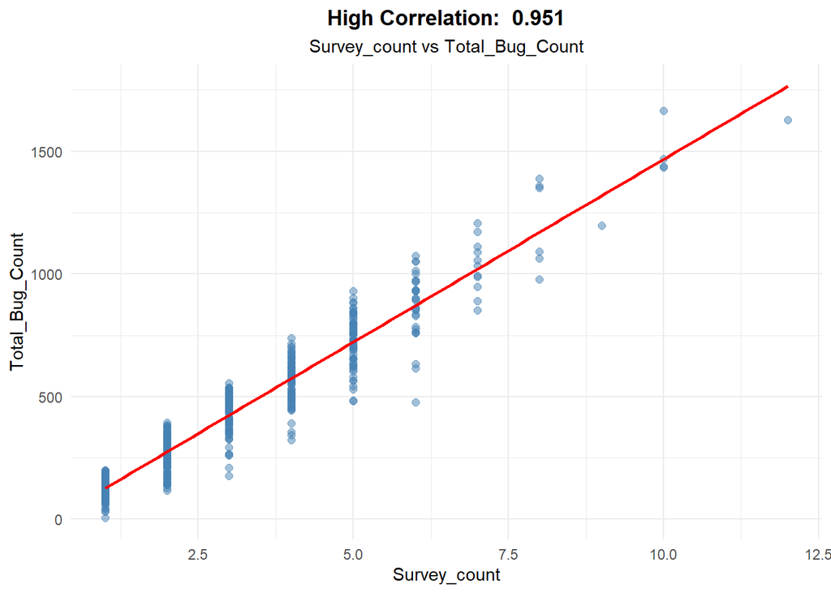

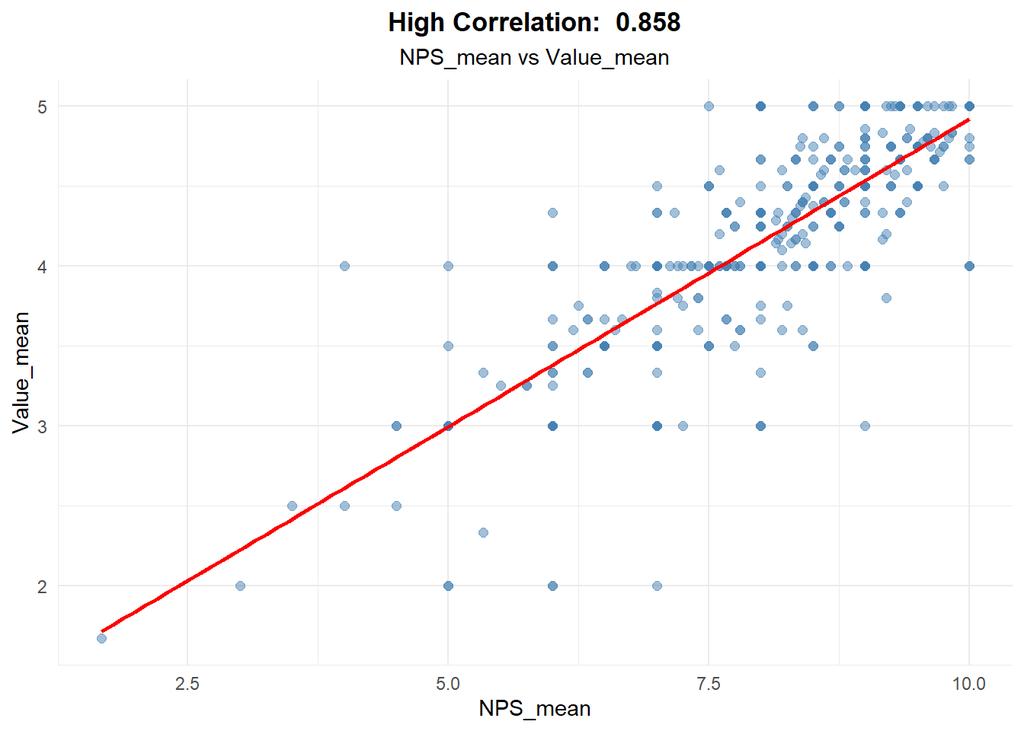

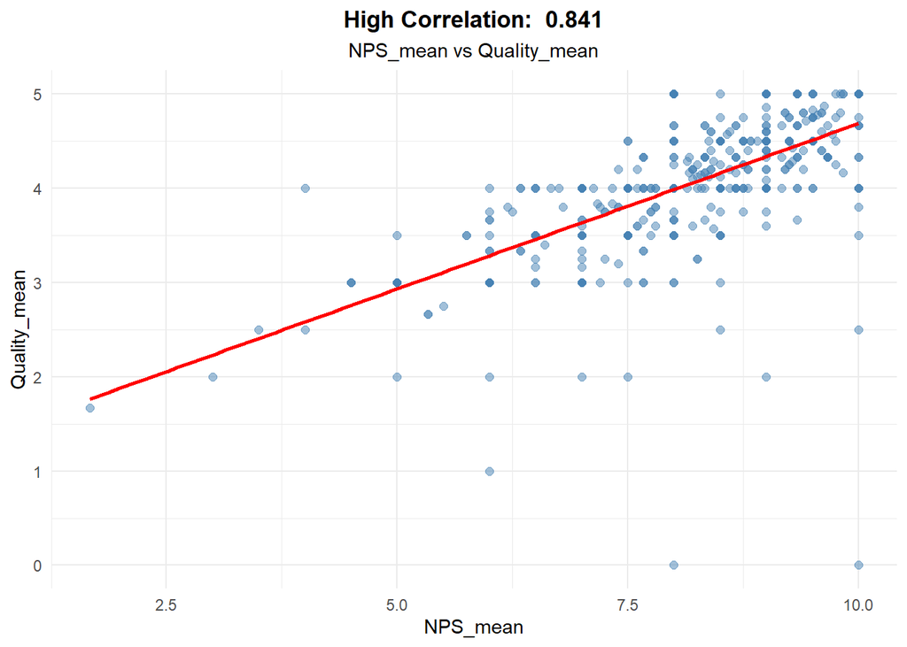

```
## High correlation scatter plots saved
```

```r
cor_matrix_raw_no_na <- cor_matrix_raw
cor_matrix_raw_no_na[is.na(cor_matrix_raw_no_na)] <- 0

high_corr_raw <- which(abs(cor_matrix_raw_no_na) > 0.8 &
                         upper.tri(cor_matrix_raw_no_na) &
                         cor_matrix_raw_no_na != 1, arr.ind = TRUE)

if (length(high_corr_raw) > 0 && nrow(high_corr_raw) > 0) {
  cat("\nHIGHLY CORRELATED VARIABLES (|r| > 0.8):\n")
  high_corr_df_raw <- data.frame(
    Variable1 = rownames(cor_matrix_raw_no_na)[high_corr_raw[, 1]],
    Variable2 = colnames(cor_matrix_raw_no_na)[high_corr_raw[, 2]],
    Correlation = cor_matrix_raw_no_na[high_corr_raw]
  )
  high_corr_df_raw <- high_corr_df_raw[order(-abs(high_corr_df_raw$Correlation)), ]
  print(high_corr_df_raw)

  write.csv(high_corr_df_raw, file.path(PROJECT_DIR, "high_correlation_raw.csv"), row.names = FALSE)
  cat("\nRaw correlation analysis saved: high_correlation_raw.csv\n")

  cat("\nHIGH CORRELATION ANALYSIS:\n")
  top_pairs <- head(high_corr_df_raw, 3)

  for (i in 1:min(3, nrow(top_pairs))) {
    var1 <- top_pairs$Variable1[i]
    var2 <- top_pairs$Variable2[i]
    corr <- top_pairs$Correlation[i]

    plot_data <- master_train[complete.cases(master_train[, c(var1, var2)]), c(var1, var2)]

    if (nrow(plot_data) > 10) {
      p <- ggplot(plot_data, aes_string(x = var1, y = var2)) +
        geom_point(alpha = 0.5, color = "steelblue", size = 2) +
        geom_smooth(method = "lm", color = "red", se = FALSE) +
        labs(
          title = paste("High Correlation: ", round(corr, 3)),
          subtitle = paste(var1, "vs", var2),
          x = var1,
          y = var2
        ) +
        theme_minimal() +
        theme(plot.title = element_text(hjust = 0.5, face = "bold"),
              plot.subtitle = element_text(hjust = 0.5))

      print(p)

      filename <- paste0("high_corr_", gsub("[^A-Za-z0-9]", "_", var1),
                         "_vs_", gsub("[^A-Za-z0-9]", "_", var2), ".png")
      ggsave(file.path(PROJECT_DIR, filename), plot = p, width = 8, height = 6)
    }
  }
  cat("High correlation scatter plots saved\n")
} else {
  cat("\nNo highly correlated variables in raw data (|r| > 0.8)\n")
}
```

```r
cat("\nCORRELATION ANALYSIS WITH STATUS:\n")
```

```
##
## CORRELATION ANALYSIS WITH STATUS:
```

```r
status_numeric <- as.numeric(master_train$Status)

status_correlations_raw <- data.frame(
  Variable = colnames(numeric_vars_raw),
  Correlation_with_Status = NA_real_,
  Abs_Correlation = NA_real_
)

for (i in 1:ncol(numeric_vars_raw)) {
  var_name <- colnames(numeric_vars_raw)[i]
  var_data <- numeric_vars_raw[[i]]

  valid_indices <- complete.cases(data.frame(var_data, status_numeric))

  if (sum(valid_indices) > 10 && sd(var_data[valid_indices], na.rm = TRUE) > 0) {
    cor_result <- cor(var_data[valid_indices], status_numeric[valid_indices], use = "complete.obs")
    status_correlations_raw$Correlation_with_Status[i] <- cor_result
    status_correlations_raw$Abs_Correlation[i] <- abs(cor_result)
  }
}

status_correlations_raw <- status_correlations_raw %>%
  filter(!is.na(Correlation_with_Status)) %>%
  arrange(-Abs_Correlation)

cat("\nVARIABLES WITH HIGHEST CORRELATION WITH STATUS:\n")
```

```
##
## VARIABLES WITH HIGHEST CORRELATION WITH STATUS:
```

```r
print(head(status_correlations_raw, 10))
```

```
##                                Variable Correlation_with_Status Abs_Correlation
## 1                 Customer.Age..Months.              0.29227166      0.29227166
## 2                     Help.Ticket.Count              0.18351574      0.18351574
## 3         Help.Ticket.Lead.Time..hours.             -0.16080254      0.16080254
## 4                       Total_Bug_Count              0.12623814      0.12623814
## 5                                   MRR              0.12131770      0.12131770
## 6                          Survey_count              0.10179369      0.10179369
## 7                            Value_mean              0.07305573      0.07305573
## 8                              NPS_mean              0.06902876      0.06902876
## 9                        Usability_mean              0.06885578      0.06885578
## 10 Company.Newsletter.Interaction.Count              0.06573775      0.06573775
```

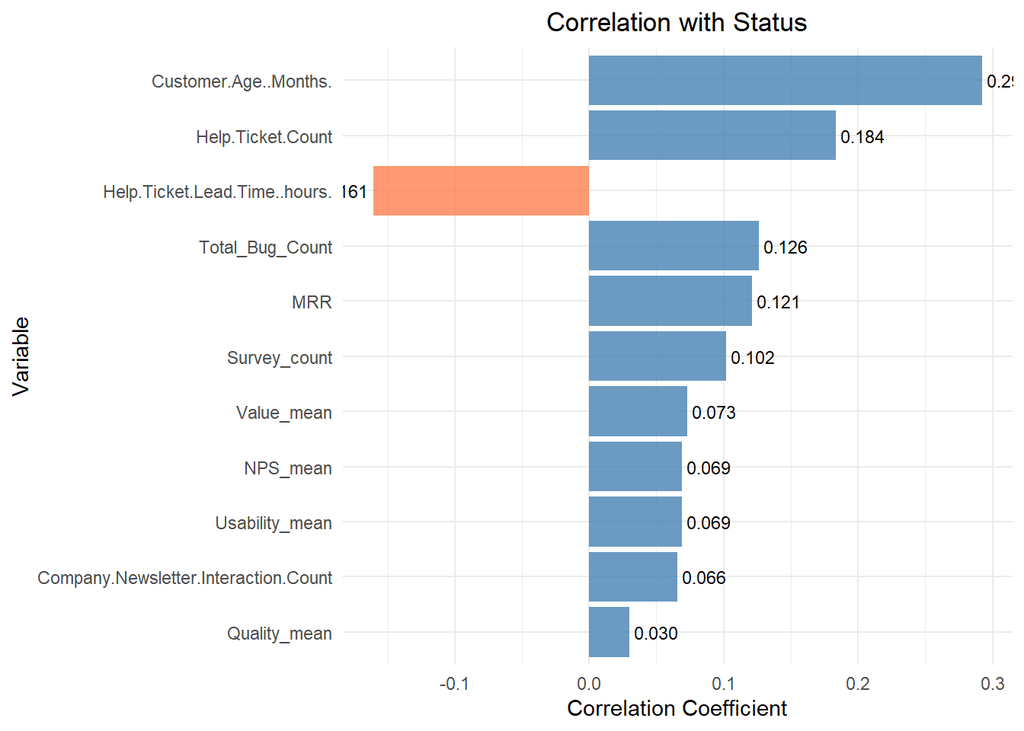

```r
n_vars_to_plot <- min(15, nrow(status_correlations_raw))
if (n_vars_to_plot > 0) {
  plot_data <- head(status_correlations_raw, n_vars_to_plot)

  p_status <- ggplot(plot_data,
                     aes(x = reorder(Variable, Abs_Correlation), y = Correlation_with_Status)) +
    geom_bar(stat = "identity",
             fill = ifelse(plot_data$Correlation_with_Status > 0, "steelblue", "coral"),
             alpha = 0.8) +
    geom_text(aes(label = sprintf("%.3f", Correlation_with_Status)),
              hjust = ifelse(plot_data$Correlation_with_Status > 0, -0.1, 1.1),
              size = 3) +
    coord_flip() +
    labs(
      title = "Correlation with Status",
      x = "Variable",
      y = "Correlation Coefficient"
    ) +
    theme_minimal() +
    theme(plot.title = element_text(hjust = 0.5))

  print(p_status)
  ggsave(file.path(PROJECT_DIR, "status_correlation.png"), plot = p_status, width = 10, height = 8)
}
```

## 8) Feature Engineering (Based on Correlation Analysis)

- Findings summary: note highly correlated pairs and variables most related to Status.
- Missing values: add flags and impute (MRR, Total.Revenue, Customer.Age..Months.).
- Survey scores: has_survey flag and median imputation for NPS_mean, Value_mean, Quality_mean, Usability_mean.
- Categorical NA: fill Reporting_score, Usage_Freq with “None”.
- Response delay: add no_response_flag and response_delay_days.
- Engagement/bug/ticket: presence flags and set missing counts to 0.
- New features: Satisfaction Composite, Support Burden, Revenue per Month, Bug Frequency, Engagement Ratio, MRR Ratio.

```r
cat("\n", strrep("=", 60), "\n")
cat("FEATURE ENGINEERING - Based on Correlation Analysis\n")
```

```
## FEATURE ENGINEERING - Based on Correlation Analysis
```

```r
cat(strrep("=", 60), "\n")
cat("\nCORRELATION ANALYSIS FINDINGS:\n")
```

```
##
## CORRELATION ANALYSIS FINDINGS:
```

```r
if (exists("high_corr_df_raw") && nrow(high_corr_df_raw) > 0) {
  cat("1. Highly correlated variable pairs:", nrow(high_corr_df_raw), "pairs\n")
  cat("   Example:", paste(head(high_corr_df_raw$Variable1, 2),
                           head(high_corr_df_raw$Variable2, 2), sep = " vs ", collapse = ", "), "\n")
} else {
  cat("1. No highly correlated variable pairs\n")
}
```

```
## 1. Highly correlated variable pairs: 3 pairs
##    Example: Survey_count vs Total_Bug_Count, NPS_mean vs Value_mean
```

```r
cat("2. Variables most related to Status identified\n")
```

```
## 2. Variables most related to Status identified
```

```r
cat("3. Feature engineering will use these insights\n")
```

```
## 3. Feature engineering will use these insights
```

```r
cat("\nMISSING VALUE PROCESSING...\n")
```

```
##
## MISSING VALUE PROCESSING...
```

```r
# Flags + imputation for core numeric fields
master_train$MRR_na_flag <- as.integer(is.na(master_train$MRR))
master_train$MRR[is.na(master_train$MRR)] <- 0

master_train$Total.Revenue_na_flag <- as.integer(is.na(master_train$Total.Revenue))
master_train$Total.Revenue[is.na(master_train$Total.Revenue)] <- 0

if ("Customer.Age..Months." %in% colnames(master_train)) {
  master_train$Customer.Age..Months.[is.na(master_train$Customer.Age..Months.)] <-
    median(master_train$Customer.Age..Months., na.rm = TRUE)
}

# Survey presence + targeted imputation
master_train$has_survey <- ifelse(is.na(master_train$NPS_mean), 0, 1)

survey_vars <- c("NPS_mean", "Value_mean", "Quality_mean", "Usability_mean")
for (var in survey_vars) {
  if (var %in% colnames(master_train)) {
    master_train[[var]][is.na(master_train[[var]])] <- median(master_train[[var]], na.rm = TRUE)
  }
}

# Categorical NA -> "None"
master_train <- master_train %>%
  mutate(
    Reporting_score = replace_na(as.character(Reporting_score), "None"),
    Usage_Freq = replace_na(as.character(Usage_Freq), "None")
  )

# Survey_count NA -> 0
master_train$Survey_count[is.na(master_train$Survey_count)] <- 0

# Response delay features
master_train$no_response_flag <- ifelse(
  is.na(master_train$Last_Response_Date) | is.na(master_train$Last_Survey_Date), 1, 0
)

master_train$response_delay_days <- as.numeric(master_train$Last_Response_Date - master_train$Last_Survey_Date)
master_train$response_delay_days[is.na(master_train$response_delay_days)] <- 0
master_train$response_delay_days[master_train$response_delay_days < 0] <- 0

# Engagement / bug / ticket flags + counts
master_train$has_newsletter_interaction <- ifelse(is.na(master_train$Company.Newsletter.Interaction.Count), 0, 1)
master_train$Company.Newsletter.Interaction.Count[is.na(master_train$Company.Newsletter.Interaction.Count)] <- 0

master_train$has_bug_report <- ifelse(is.na(master_train$Total_Bug_Count), 0, 1)
master_train$Total_Bug_Count[is.na(master_train$Total_Bug_Count)] <- 0

master_train$has_ticket <- ifelse(is.na(master_train$Help.Ticket.Count), 0, 1)
master_train$Help.Ticket.Count[is.na(master_train$Help.Ticket.Count)] <- 0

master_train$Help.Ticket.Lead.Time..hours.[is.na(master_train$Help.Ticket.Lead.Time..hours.)] <- 0

cat("\nCreating new features...\n")
```

```
##
## Creating new features...
```

```r
# Satisfaction Composite
master_train$Satisfaction_Composite <- rowMeans(
  master_train[, c("NPS_mean", "Value_mean", "Quality_mean", "Usability_mean")],
  na.rm = TRUE
)

# Support Burden
master_train$Support_Burden <- master_train$Help.Ticket.Count *
  ifelse(master_train$Help.Ticket.Lead.Time..hours. > 0,
         master_train$Help.Ticket.Lead.Time..hours., 1)

# Revenue per month
master_train$Revenue_per_Month <- ifelse(
  master_train$Customer.Age..Months. > 0,
  master_train$Total.Revenue / master_train$Customer.Age..Months.,
  0
)

# Bug frequency
master_train$Bug_Frequency <- ifelse(
  master_train$Customer.Age..Months. > 0,
  master_train$Total_Bug_Count / master_train$Customer.Age..Months.,
  0
)

# Engagement ratio
master_train$Engagement_Ratio <- ifelse(
  master_train$Customer.Age..Months. > 0,
  master_train$Company.Newsletter.Interaction.Count / master_train$Customer.Age..Months.,
  0
)

# MRR to revenue ratio
master_train$MRR_Ratio <- ifelse(
  master_train$Total.Revenue > 0,
  master_train$MRR / master_train$Total.Revenue,
  0
)

cat("6 new features created.\n")
```

```
## 6 new features created.
```

## 9) Post-Correlation Analysis Check

- Numeric selection: re-select numeric features and drop Year_Last, Quarter_Last.
- Constant removal: remove zero-variance columns.
- Final matrix + heatmap: compute Pearson correlation and save a final heatmap.
- High correlations: list |r| > 0.8 pairs, sort, and save to CSV.
- Status link: compute correlations of final features with Status; visualize new features.

```r
cat("\n", strrep("=", 60), "\n")
cat("CORRELATION ANALYSIS - After Feature Engineering\n")
```

```
## CORRELATION ANALYSIS - After Feature Engineering
```

```r
cat(strrep("=", 60), "\n")
numeric_vars_final <- master_train %>%
  select(where(is.numeric)) %>%
  select(-Year_Last, -Quarter_Last)

zero_sd_vars_final <- names(which(apply(numeric_vars_final, 2, function(x) sd(x, na.rm = TRUE)) == 0))
if (length(zero_sd_vars_final) > 0) {
  cat("Removing constant value variables:", paste(zero_sd_vars_final, collapse = ", "), "\n")
  numeric_vars_final <- numeric_vars_final %>% select(-all_of(zero_sd_vars_final))
}

cat("Number of numeric variables after feature engineering:", ncol(numeric_vars_final), "\n")
```

```
## Number of numeric variables after feature engineering: 26
```

```r
complete_cases_final <- complete.cases(numeric_vars_final)
if (sum(complete_cases_final) < 10) {
  cor_matrix_final <- cor(numeric_vars_final, use = "pairwise.complete.obs", method = "pearson")
} else {
  cor_matrix_final <- cor(numeric_vars_final[complete_cases_final, ], use = "complete.obs", method = "pearson")
}

png(file.path(PROJECT_DIR, "correlation_final_after_fe.png"), width = 1200, height = 1000)
corrplot(cor_matrix_final,
         method = "color",
         type = "upper",
         tl.col = "black",
         tl.cex = 0.6,
         number.cex = 0.5,
         title = "FINAL CORRELATION MATRIX (After Feature Engineering)",
         mar = c(0, 0, 2, 0))
dev.off()
```

```r
cat("Final correlation heatmap saved: correlation_final_after_fe.png\n")
```

```
## Final correlation heatmap saved: correlation_final_after_fe.png
```

```r
cor_matrix_final_no_na <- cor_matrix_final
cor_matrix_final_no_na[is.na(cor_matrix_final_no_na)] <- 0

high_corr_final <- which(abs(cor_matrix_final_no_na) > 0.8 &
                           upper.tri(cor_matrix_final_no_na) &
                           cor_matrix_final_no_na != 1, arr.ind = TRUE)

if (length(high_corr_final) > 0 && nrow(high_corr_final) > 0) {
  cat("\nHIGHLY CORRELATED VARIABLES AFTER FEATURE ENGINEERING (|r| > 0.8):\n")
  high_corr_df_final <- data.frame(
    Variable1 = rownames(cor_matrix_final_no_na)[high_corr_final[, 1]],
    Variable2 = colnames(cor_matrix_final_no_na)[high_corr_final[, 2]],
    Correlation = cor_matrix_final_no_na[high_corr_final]
  )
  high_corr_df_final <- high_corr_df_final[order(-abs(high_corr_df_final$Correlation)), ]
  print(high_corr_df_final)

  write.csv(high_corr_df_final, file.path(PROJECT_DIR, "high_correlation_final.csv"), row.names = FALSE)
  cat("\nFinal correlation analysis saved: high_correlation_final.csv\n")
} else {
  cat("\nNo highly correlated variables after feature engineering (|r| > 0.8)\n")
}
```

```
##
## HIGHLY CORRELATED VARIABLES AFTER FEATURE ENGINEERING (|r| > 0.8):
##              Variable1              Variable2 Correlation
## 4           has_survey       no_response_flag  -1.0000000
## 8           has_survey         has_bug_report   1.0000000
## 9     no_response_flag         has_bug_report  -1.0000000
## 1         Survey_count        Total_Bug_Count   0.9850988
## 15       Total.Revenue      Revenue_per_Month   0.9311334
## 5           has_survey    response_delay_days   0.9284620
## 6     no_response_flag    response_delay_days  -0.9284620
## 10 response_delay_days         has_bug_report   0.9284620
## 11            NPS_mean Satisfaction_Composite   0.9194607
## 14   Help.Ticket.Count         Support_Burden   0.9034724
## 12          Value_mean Satisfaction_Composite   0.8917218
## 13        Quality_mean Satisfaction_Composite   0.8333682
## 2         Survey_count             has_survey   0.8223266
## 3         Survey_count       no_response_flag  -0.8223266
## 7         Survey_count         has_bug_report   0.8223266
##
## Final correlation analysis saved: high_correlation_final.csv
```

```r
status_correlations_final <- data.frame(
  Variable = colnames(numeric_vars_final),
  Correlation_with_Status = NA_real_,
  Abs_Correlation = NA_real_
)

for (i in 1:ncol(numeric_vars_final)) {
  var_name <- colnames(numeric_vars_final)[i]
  var_data <- numeric_vars_final[[i]]

  valid_indices <- complete.cases(data.frame(var_data, status_numeric))

  if (sum(valid_indices) > 10 && sd(var_data[valid_indices], na.rm = TRUE) > 0) {
    cor_result <- cor(var_data[valid_indices], status_numeric[valid_indices],
                      use = "complete.obs")
    status_correlations_final$Correlation_with_Status[i] <- cor_result
    status_correlations_final$Abs_Correlation[i] <- abs(cor_result)
  }
}

status_correlations_final <- status_correlations_final %>%
  filter(!is.na(Correlation_with_Status)) %>%
  arrange(-Abs_Correlation)

cat("\nNEW VARIABLES WITH HIGHEST CORRELATION WITH STATUS:\n")
```

```
##
## NEW VARIABLES WITH HIGHEST CORRELATION WITH STATUS:
```

```r
print(head(status_correlations_final, 10))
```

```
##                 Variable Correlation_with_Status Abs_Correlation
## 1            MRR_na_flag              -0.8425437       0.8425437
## 2  Total.Revenue_na_flag              -0.8254495       0.8254495
## 3       no_response_flag              -0.5555952       0.5555952
## 4             has_survey               0.5555952       0.5555952
## 5         has_bug_report               0.5555952       0.5555952
## 6    response_delay_days               0.5263850       0.5263850
## 7             has_ticket               0.5175495       0.5175495
## 8           Survey_count               0.4726152       0.4726152
## 9        Total_Bug_Count               0.4635758       0.4635758
## 10                   MRR               0.4303247       0.4303247
```

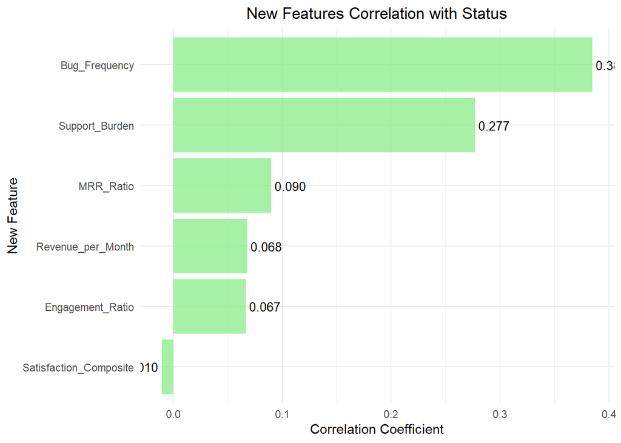

```r
new_features <- c("Satisfaction_Composite", "Support_Burden", "Revenue_per_Month",
                  "Bug_Frequency", "Engagement_Ratio", "MRR_Ratio")
new_features_data <- status_correlations_final %>%
  filter(Variable %in% new_features)

if (nrow(new_features_data) > 0) {
  p_new_features <- ggplot(new_features_data,
                           aes(x = reorder(Variable, Abs_Correlation), y = Correlation_with_Status)) +
    geom_bar(stat = "identity", fill = "lightgreen", alpha = 0.8) +
    geom_text(aes(label = sprintf("%.3f", Correlation_with_Status)),
              hjust = ifelse(new_features_data$Correlation_with_Status > 0, -0.1, 1.1),
              size = 3.5) +
    coord_flip() +
    labs(
      title = "New Features Correlation with Status",
      x = "New Feature",
      y = "Correlation Coefficient"
    ) +
    theme_minimal() +
    theme(plot.title = element_text(hjust = 0.5))

  print(p_new_features)
  ggsave(file.path(PROJECT_DIR, "new_features_correlation.png"),
         plot = p_new_features, width = 10, height = 6)
}
```

## 10) Variable Selection and Model Preparation - Selection criteria: - Variables most correlated with Status - Remove one from highly correlated pairs (multicollinearity control) - Include newly engineered features -Exclusions: - IDs and dates (Customer.ID, Last_Survey_Date, Last_Response_Date) - Original variables replaced by new composites (e.g., NPS_mean, Help.Ticket.Count)

```r
 cat("\n", strrep("=", 60), "\n")
cat("VARIABLE SELECTION AND MODEL PREPARATION\n")
```

```
## VARIABLE SELECTION AND MODEL PREPARATION
```

```r
cat(strrep("=", 60), "\n")
cat("\nVARIABLE SELECTION CRITERIA:\n")
```

```
##
## VARIABLE SELECTION CRITERIA:
```

```r
cat("1. Variables with highest correlation with Status\n")
```

```
## 1. Variables with highest correlation with Status
```

```r
cat("2. Remove one from highly correlated pairs\n")
```

```
## 2. Remove one from highly correlated pairs
```

```r
cat("3. Include newly created features\n")
```

```
## 3. Include newly created features
```

```r
# Base selection: drop ID and date fields
master_model <- master_train %>%
  select(-Customer.ID, -Last_Survey_Date, -Last_Response_Date)

# Remove original variables that are represented by engineered features
variables_to_remove <- c(
  "NPS_mean", "Value_mean", "Quality_mean", "Usability_mean",
  "Help.Ticket.Count", "Help.Ticket.Lead.Time..hours."
)

cat("\nREMOVING VARIABLES TO PREVENT MULTICOLLINEARITY:\n")
```

```
##
## REMOVING VARIABLES TO PREVENT MULTICOLLINEARITY:
```

```r
for (var in variables_to_remove) {
  if (var %in% colnames(master_model)) {
    cat("  -", var, "removed\n")
  }
}
```

```
##   - NPS_mean removed
##   - Value_mean removed
##   - Quality_mean removed
##   - Usability_mean removed
##   - Help.Ticket.Count removed
##   - Help.Ticket.Lead.Time..hours. removed
```

```r
master_model <- master_model %>% select(-any_of(variables_to_remove))

# Ensure categorical columns are factors
cat_cols <- c("Region", "Customer.Level", "Vertical", "Subvertical", "Usage_Freq", "Reporting_score")
for (col in cat_cols) {
  if (col %in% colnames(master_model)) {
    master_model[[col]] <- as.factor(as.character(master_model[[col]]))
  }
}

# Drop one of highly correlated numeric variables (cutoff = 0.8)
num_mat <- master_model %>% select(where(is.numeric))
if (ncol(num_mat) > 1) {
  cor_mat <- cor(num_mat, use = "pairwise.complete.obs", method = "pearson")
  cor_mat[is.na(cor_mat)] <- 0
  hc_names <- caret::findCorrelation(cor_mat, cutoff = 0.8, names = TRUE, verbose = FALSE)
  if (length(hc_names) > 0) {
    cat("\nRemoving highly correlated variables (cutoff=0.8): ", paste(hc_names, collapse = ", "), "\n", sep = "")
    master_model <- master_model %>% select(-all_of(hc_names))
  } else {
    cat("\nNo variables removed by high correlation filter.\n")
  }
}
```

```
##
## Removing highly correlated variables (cutoff=0.8): Survey_count, has_survey, no_response_flag, has_bug_report, Revenue_per_Month
```

```r
# NA handling: numeric -> median, factor -> mode
cat("\nCHECKING NA VALUES IN FINAL MODEL DATA SET...\n")
```

```
##
## CHECKING NA VALUES IN FINAL MODEL DATA SET...
```

```r
na_summary <- sapply(master_model, function(x) sum(is.na(x)))
na_vars <- names(na_summary[na_summary > 0])

if (length(na_vars) > 0) {
  cat("Variables containing NA:", length(na_vars), "\n")
  cat("   Total NA count:", sum(na_summary), "\n")

  is_num <- sapply(master_model, is.numeric)
  is_fac <- sapply(master_model, is.factor)

  for (var in na_vars) {
    if (isTRUE(is_num[var])) {
      master_model[[var]][is.na(master_model[[var]])] <- median(master_model[[var]], na.rm = TRUE)
      cat("   -", var, ": NA values filled with median (", na_summary[var], " NA)\n", sep = "")
    } else if (isTRUE(is_fac[var])) {
      mode_val <- names(sort(table(master_model[[var]]), decreasing = TRUE))[1]
      master_model[[var]][is.na(master_model[[var]])] <- mode_val
      cat("   -", var, ": NA values filled with mode(", mode_val, ") (", na_summary[var], " NA)\n", sep = "")
    }
  }
}
```

```
## Variables containing NA: 2
##    Total NA count: 3132
##    -Year_Last: NA values filled with median (1566 NA)
##    -Quarter_Last: NA values filled with median (1566 NA)
```

```r
cat("\nFINAL MODEL DATA SET:\n")
```

```
##
## FINAL MODEL DATA SET:
```

```r
cat("Number of rows:", nrow(master_model), "\n")
```

```
## Number of rows: 2068
```

```r
cat("Number of columns:", ncol(master_model), "\n")
```

```
## Number of columns: 24
```

```r
cat("NA count (after correction):", sum(is.na(master_model)), "\n")
```

```
## NA count (after correction): 0
```

```r
cat("Status distribution:\n")
```

```
## Status distribution:
```

```r
print(table(master_model$Status))
```

```
##
##      Churn Onboarding   Retained
##        972        256        840
```

## 11) Post-Cleaning Correlation Analysis (2nd Analysis)

- Numeric selection: use cleaned master_model numerics; drop constant columns.
- Final matrix + heatmap: compute Pearson correlation and save the plot.
- High correlations: list |r| > 0.8 pairs, sort, and save CSV.
- Status link: compute correlations with Status and export a comparison chart.
- Comparison: summarize variable counts and high-correlation reduction vs. earlier phases.

```r
cat("\n", strrep("=", 60), "\n")
cat("POST-CLEANING CORRELATION ANALYSIS (2nd Analysis)\n")
```

```
## POST-CLEANING CORRELATION ANALYSIS (2nd Analysis)
```

```r
cat(strrep("=", 60), "\n")
## 11.1 Select numeric variables after cleaning
numeric_vars_clean <- master_model %>%
  select(where(is.numeric))

# Remove constant value variables
zero_sd_vars_clean <- names(which(apply(numeric_vars_clean, 2, function(x) sd(x, na.rm = TRUE)) == 0))
if (length(zero_sd_vars_clean) > 0) {
  cat("Removing constant value variables:", paste(zero_sd_vars_clean, collapse = ", "), "\n")
  numeric_vars_clean <- numeric_vars_clean %>% select(-all_of(zero_sd_vars_clean))
}
```

```
## Removing constant value variables: Year_Last
```

```r
cat("Number of numeric variables after cleaning:", ncol(numeric_vars_clean), "\n")
```

```
## Number of numeric variables after cleaning: 16
```

```r
cat("Variables:", paste(colnames(numeric_vars_clean), collapse = ", "), "\n")
```

[output not shown]

```r
## 11.2 Post-cleaning correlation matrix
complete_cases_clean <- complete.cases(numeric_vars_clean)
if (sum(complete_cases_clean) < 10) {
  cor_matrix_clean <- cor(numeric_vars_clean, use = "pairwise.complete.obs", method = "pearson")
} else {
  cor_matrix_clean <- cor(numeric_vars_clean[complete_cases_clean, ], use = "complete.obs", method = "pearson")
}

cat("Post-cleaning correlation matrix dimensions:", dim(cor_matrix_clean), "\n")
```

```
## Post-cleaning correlation matrix dimensions: 16 16
```

```r
## 11.3 Create post-cleaning heatmap
cat("\nCreating post-cleaning correlation heatmap...\n")
```

```
##
## Creating post-cleaning correlation heatmap...
```

```r
png(file.path(PROJECT_DIR, "correlation_clean_after_removal.png"), width = 1200, height = 1000)
corrplot(cor_matrix_clean,
         method = "color",
         type = "upper",
         tl.col = "black",
         tl.cex = 0.6,
         number.cex = 0.5,
         title = "POST-CLEANING CORRELATION MATRIX (After Multicollinearity Prevention)",
         mar = c(0, 0, 2, 0))
dev.off()
```

```r
cat("Post-cleaning correlation heatmap saved: correlation_clean_after_removal.png\n")
```

```
## Post-cleaning correlation heatmap saved: correlation_clean_after_removal.png
```

```r
## 11.4 Post-cleaning high correlation check
cor_matrix_clean_no_na <- cor_matrix_clean
cor_matrix_clean_no_na[is.na(cor_matrix_clean_no_na)] <- 0

high_corr_clean <- which(abs(cor_matrix_clean_no_na) > 0.8 &
                           upper.tri(cor_matrix_clean_no_na) &
                           cor_matrix_clean_no_na != 1, arr.ind = TRUE)

if (length(high_corr_clean) > 0 && nrow(high_corr_clean) > 0) {
  cat("\nHIGHLY CORRELATED VARIABLES AFTER CLEANING (|r| > 0.8):\n")
  high_corr_df_clean <- data.frame(
    Variable1 = rownames(cor_matrix_clean_no_na)[high_corr_clean[, 1]],
    Variable2 = colnames(cor_matrix_clean_no_na)[high_corr_clean[, 2]],
    Correlation = cor_matrix_clean_no_na[high_corr_clean]
  )
  high_corr_df_clean <- high_corr_df_clean[order(-abs(high_corr_df_clean$Correlation)), ]
  print(high_corr_df_clean)

  write.csv(high_corr_df_clean, file.path(PROJECT_DIR, "high_correlation_clean.csv"), row.names = FALSE)
  cat("\nPost-cleaning correlation analysis saved: high_correlation_clean.csv\n")
} else {
  cat("\nNo highly correlated variables after cleaning (|r| > 0.8)\n")
}
```

```
##
## No highly correlated variables after cleaning (|r| > 0.8)
```

```r
# Section 11.4'ün sonuna ekleyin
if (!exists("high_corr_df_clean")) {
  high_corr_df_clean <- data.frame(Variable1=character(), Variable2=character(), Correlation=numeric())
}
## 11.5 Post-cleaning Correlation with Status analysis
status_correlations_clean <- data.frame(
  Variable = colnames(numeric_vars_clean),
  Correlation_with_Status = NA_real_,
  Abs_Correlation = NA_real_
)

for (i in 1:ncol(numeric_vars_clean)) {
  var_name <- colnames(numeric_vars_clean)[i]
  var_data <- numeric_vars_clean[[i]]

  valid_indices <- complete.cases(data.frame(var_data, status_numeric))

  if (sum(valid_indices) > 10 && sd(var_data[valid_indices], na.rm = TRUE) > 0) {
    cor_result <- cor(var_data[valid_indices], status_numeric[valid_indices],
                      use = "complete.obs")
    status_correlations_clean$Correlation_with_Status[i] <- cor_result
    status_correlations_clean$Abs_Correlation[i] <- abs(cor_result)
  }
}

status_correlations_clean <- status_correlations_clean %>%
  filter(!is.na(Correlation_with_Status)) %>%
  arrange(-Abs_Correlation)

cat("\nVARIABLES WITH HIGHEST CORRELATION WITH STATUS AFTER CLEANING:\n")
```

```
##
## VARIABLES WITH HIGHEST CORRELATION WITH STATUS AFTER CLEANING:
```

```r
print(head(status_correlations_clean, 10))
```

```
##                      Variable Correlation_with_Status Abs_Correlation
## 1                 MRR_na_flag              -0.8425437       0.8425437
## 2       Total.Revenue_na_flag              -0.8254495       0.8254495
## 3         response_delay_days               0.5263850       0.5263850
## 4                  has_ticket               0.5175495       0.5175495
## 5             Total_Bug_Count               0.4635758       0.4635758
## 6                         MRR               0.4303247       0.4303247
## 7               Bug_Frequency               0.3848999       0.3848999
## 8       Customer.Age..Months.               0.2922717       0.2922717
## 9              Support_Burden               0.2772294       0.2772294
## 10 has_newsletter_interaction               0.2207088       0.2207088
```

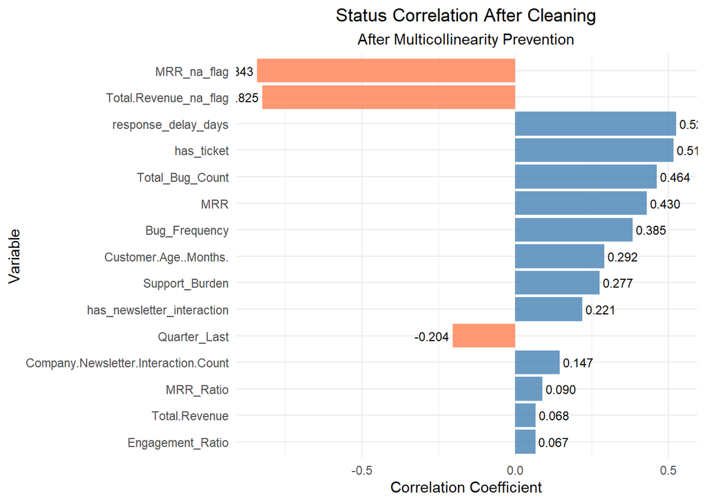

```r
# Post-cleaning Status correlation graph
n_vars_to_plot_clean <- min(15, nrow(status_correlations_clean))
if (n_vars_to_plot_clean > 0) {
  plot_data_clean <- head(status_correlations_clean, n_vars_to_plot_clean)

  p_status_clean <- ggplot(plot_data_clean,
                           aes(x = reorder(Variable, Abs_Correlation), y = Correlation_with_Status)) +
    geom_bar(stat = "identity",
             fill = ifelse(plot_data_clean$Correlation_with_Status > 0, "steelblue", "coral"),
             alpha = 0.8) +
    geom_text(aes(label = sprintf("%.3f", Correlation_with_Status)),
              hjust = ifelse(plot_data_clean$Correlation_with_Status > 0, -0.1, 1.1),
              size = 3) +
    coord_flip() +
    labs(
      title = "Status Correlation After Cleaning",
      subtitle = "After Multicollinearity Prevention",
      x = "Variable",
      y = "Correlation Coefficient"
    ) +
    theme_minimal() +
    theme(plot.title = element_text(hjust = 0.5),
          plot.subtitle = element_text(hjust = 0.5))

  print(p_status_clean)
  ggsave(file.path(PROJECT_DIR, "status_correlation_clean.png"),
         plot = p_status_clean, width = 10, height = 8)
}
```

```r
## 11.6 Correlation analysis comparison
cat("\nCORRELATION ANALYSIS COMPARISON:\n")
```

```
##
## CORRELATION ANALYSIS COMPARISON:
```

```r
cat("1. Before Feature Engineering: ", ncol(numeric_vars_raw), " variables\n")
```

```
## 1. Before Feature Engineering:  12  variables
```

```r
cat("2. After Feature Engineering: ", ncol(numeric_vars_final), " variables\n")
```

```
## 2. After Feature Engineering:  26  variables
```

```r
cat("3. After Cleaning: ", ncol(numeric_vars_clean), " variables\n")
```

```
## 3. After Cleaning:  16  variables
```

```r
if (exists("high_corr_df_raw") && exists("high_corr_df_clean")) {
  cat("\nHIGH CORRELATION REDUCTION SUCCESS:\n")
  cat("   Initial high correlation pairs: ", nrow(high_corr_df_raw), "\n")
  cat("   Post-cleaning high correlation pairs: ", nrow(high_corr_df_clean), "\n")

  if (nrow(high_corr_df_raw) > 0 && nrow(high_corr_df_clean) > 0) {
    reduction <- round(100 * (1 - nrow(high_corr_df_clean) / nrow(high_corr_df_raw)), 1)
    cat("   High correlation reduction rate: %", reduction, "\n")
  }
}
```

```
##
## HIGH CORRELATION REDUCTION SUCCESS:
##    Initial high correlation pairs:  3
##    Post-cleaning high correlation pairs:  0
```

## 12) Train / Validation Split (Stratified)

- Strategy: stratified split by Status with 80/20 ratio using caret::createDataPartition().
- Checks: print set sizes and class distributions to verify stratification.

```r
cat("\nTRAIN/VALIDATION SPLIT...\n")
```

```
##
## TRAIN/VALIDATION SPLIT...
```

```r
trainIndex <- createDataPartition(master_model$Status, p = 0.8, list = FALSE)
train_data <- master_model[trainIndex, ]
valid_data <- master_model[-trainIndex, ]

cat("Train set size:", nrow(train_data), "\n")
```

```
## Train set size: 1655
```

```r
cat("Validation set size:", nrow(valid_data), "\n")
```

```
## Validation set size: 413
```

```r
cat("Train distribution:\n")
```

```
## Train distribution:
```

```r
print(table(train_data$Status))
```

```
##
##      Churn Onboarding   Retained
##        778        205        672
```

```r
cat("Validation distribution:\n")
```

```
## Validation distribution:
```

```r
print(table(valid_data$Status))
```

```
##
##      Churn Onboarding   Retained
##        194         51        168
```

## 13) One‑Hot Encoding (ONLY ON TRAIN)

- Targets: categorical columns Region, Customer.Level, Vertical, Subvertical, Usage_Freq, Reporting_score.
- Method: caret::dummyVars() with fullRank = TRUE to avoid perfect multicollinearity.
- Output: append dummy columns to numeric features for train/validation consistently.

```r
cat("\nONE-HOT ENCODING...\n")
```

```
##
## ONE-HOT ENCODING...
```

```r
# Ensure cat_cols is available
if (!exists("cat_cols")) {
  cat_cols <- c("Region", "Customer.Level", "Vertical", "Subvertical", "Usage_Freq", "Reporting_score")
}

dummies <- dummyVars(
  ~ Region + Customer.Level + Vertical + Subvertical + Usage_Freq + Reporting_score,
  data = train_data,
  fullRank = TRUE
)

train_dummy <- predict(dummies, newdata = train_data) %>% as.data.frame()
valid_dummy <- predict(dummies, newdata = valid_data) %>% as.data.frame()

train_final <- bind_cols(
  train_data %>% select(-all_of(cat_cols)),
  train_dummy
)

valid_final <- bind_cols(
  valid_data %>% select(-all_of(cat_cols)),
  valid_dummy
)

cat("Train size after one-hot encoding:", dim(train_final), "\n")
```

```
## Train size after one-hot encoding: 1655 125
```

```r
cat("Validation size after one-hot encoding:", dim(valid_final), "\n")
```

```
## Validation size after one-hot encoding: 413 125
```

## 14) Model Training

- Control: 5-fold CV, class probabilities, multiClassSummary metrics.
- NA safety: fill remaining NAs (median for numerics) in train_final and mirror to valid_final.
- Models:
- Random Forest (caret::train(method = “rf”)) + validation confusion matrix
- Multinomial Logistic (nnet::multinom) + validation confusion matrix
- GBM (caret::train(method = “gbm”)) with a small grid + validation confusion matrix

```r
cat("\n", strrep("=", 60), "\n")
cat("MODEL TRAINING\n")
```

```
## MODEL TRAINING
```

```r
cat(strrep("=", 60), "\n")
set.seed(42)
ctrl <- trainControl(
  method = "cv",
  number = 5,
  classProbs = TRUE,
  savePredictions = "final",
  summaryFunction = multiClassSummary,
  verboseIter = FALSE
)

cat("\nNA VALUE CHECK...\n")
```

```
##
## NA VALUE CHECK...
```

```r
na_count <- sum(is.na(train_final))
cat("Total NA count in train_final:", na_count, "\n")
```

```
## Total NA count in train_final: 0
```

```r
if (na_count > 0) {
  cat("NA values found! Correcting...\n")
  na_columns <- colnames(train_final)[apply(train_final, 2, function(x) any(is.na(x)))]
  cat("Columns containing NA:", paste(na_columns, collapse = ", "), "\n")

  numeric_cols <- sapply(train_final, is.numeric)
  for (col in na_columns) {
    if (numeric_cols[col]) {
      train_final[[col]][is.na(train_final[[col]])] <- median(train_final[[col]], na.rm = TRUE)
      cat("  -", col, ": NA values filled with median\n")
    }
  }

  if (exists("valid_final")) {
    for (col in na_columns) {
      if (col %in% colnames(valid_final)) {
        if (numeric_cols[col]) {
          valid_final[[col]][is.na(valid_final[[col]])] <- median(valid_final[[col]], na.rm = TRUE)
        }
      }
    }
    cat("NA corrections also applied to valid_final\n")
  }

  na_count_after <- sum(is.na(train_final))
  cat("Total NA in train_final after correction:", na_count_after, "\n")
}

cat("\nRANDOM FOREST TRAINING...\n")
```

```
##
## RANDOM FOREST TRAINING...
```

```r
set.seed(42)
tryCatch({
  rf_model <- train(
    Status ~ .,
    data = train_final,
    method = "rf",
    trControl = ctrl,
    metric = "Accuracy",
    tuneLength = 3,
    importance = TRUE,
    ntree = 200
  )
  cat("Random Forest results:\n")
  print(rf_model)

  if (exists("valid_final") && sum(is.na(valid_final)) == 0) {
    rf_pred <- predict(rf_model, newdata = valid_final)
    cm_rf <- confusionMatrix(rf_pred, valid_final$Status)
    print(cm_rf)
  } else {
    cat("Valid_final contains NA values or doesn't exist\n")
  }
}, error = function(e) {
  cat("Random Forest error:", e$message, "\n")
})
```

```
## Random Forest results:
## Random Forest
##
## 1655 samples
##  124 predictor
##    3 classes: 'Churn', 'Onboarding', 'Retained'
##
## No pre-processing
## Resampling: Cross-Validated (5 fold)
## Summary of sample sizes: 1324, 1324, 1323, 1325, 1324
## Resampling results across tuning parameters:
##
##   mtry  logLoss    AUC        prAUC      Accuracy   Kappa      Mean_F1
##     2   0.4687990  0.9609371  0.8672008  0.8126826  0.6632222  0.6224843
##    63   0.4952358  0.9766562  0.5266683  0.9341315  0.8898012  0.9106457
##   124   0.5883101  0.9760278  0.4197818  0.9268825  0.8782271  0.9019557
##   Mean_Sensitivity  Mean_Specificity  Mean_Pos_Pred_Value  Mean_Neg_Pred_Value
##   0.6222693         0.8846001         0.7757227            0.9179699
##   0.9096731         0.9644331         0.9131010            0.9655951
##   0.9055986         0.9614319         0.8999455            0.9610864
##   Mean_Precision  Mean_Recall  Mean_Detection_Rate  Mean_Balanced_Accuracy
##   0.7757227       0.6222693    0.2708942            0.7534347
##   0.9131010       0.9096731    0.3113772            0.9370531
##   0.8999455       0.9055986    0.3089608            0.9335152
##
## Accuracy was used to select the optimal model using the largest value.
## The final value used for the model was mtry = 63.
## Confusion Matrix and Statistics
##
##             Reference
## Prediction   Churn Onboarding Retained
##   Churn        188          4        5
##   Onboarding     2         46        4
##   Retained       4          1      159
##
## Overall Statistics
##
##                Accuracy : 0.9516
##                  95% CI : (0.9262, 0.9702)
##     No Information Rate : 0.4697
##     P-Value [Acc > NIR] : <2e-16
##
##                   Kappa : 0.9191
##
##  Mcnemar's Test P-Value : 0.4614
##
## Statistics by Class:
##
##                      Class: Churn Class: Onboarding Class: Retained
## Sensitivity                0.9691            0.9020          0.9464
## Specificity                0.9589            0.9834          0.9796
## Pos Pred Value             0.9543            0.8846          0.9695
## Neg Pred Value             0.9722            0.9861          0.9639
## Prevalence                 0.4697            0.1235          0.4068
## Detection Rate             0.4552            0.1114          0.3850
## Detection Prevalence       0.4770            0.1259          0.3971
## Balanced Accuracy          0.9640            0.9427          0.9630
```

```r
cat("\nLOGISTIC REGRESSION TRAINING...\n")
```

```
##
## LOGISTIC REGRESSION TRAINING...
```

```r
set.seed(42)
tryCatch({
  if (sum(is.na(train_final)) == 0) {
    log_model <- multinom(
      Status ~ .,
      data = train_final,
      MaxNWts = 10000,
      trace = FALSE
    )
    log_pred <- predict(log_model, newdata = valid_final)
    cm_log <- confusionMatrix(log_pred, valid_final$Status)
    print(cm_log)
  } else {
    cat("Train_final contains NA values, skipping Logistic Regression\n")
    log_model <- NULL
  }
}, error = function(e) {
  cat("Logistic Regression error:", e$message, "\n")
  log_model <- NULL
})
```

```
## Confusion Matrix and Statistics
##
##             Reference
## Prediction   Churn Onboarding Retained
##   Churn        179          7        6
##   Onboarding     7         38        3
##   Retained       8          6      159
##
## Overall Statistics
##
##                Accuracy : 0.9104
##                  95% CI : (0.8786, 0.9361)
##     No Information Rate : 0.4697
##     P-Value [Acc > NIR] : <2e-16
##
##                   Kappa : 0.8499
##
##  Mcnemar's Test P-Value : 0.7325
##
## Statistics by Class:
##
##                      Class: Churn Class: Onboarding Class: Retained
## Sensitivity                0.9227           0.74510          0.9464
## Specificity                0.9406           0.97238          0.9429
## Pos Pred Value             0.9323           0.79167          0.9191
## Neg Pred Value             0.9321           0.96438          0.9625
## Prevalence                 0.4697           0.12349          0.4068
## Detection Rate             0.4334           0.09201          0.3850
## Detection Prevalence       0.4649           0.11622          0.4189
## Balanced Accuracy          0.9317           0.85874          0.9446
```

```r
cat("\nGBM TRAINING...\n")
```

```
##
## GBM TRAINING...
```

```r
set.seed(42)
ctrl_gbm <- trainControl(
  method = "cv",
  number = 3,
  classProbs = TRUE,
  savePredictions = "final",
  summaryFunction = multiClassSummary,
  verboseIter = FALSE
)

tryCatch({
  if (sum(is.na(train_final)) == 0) {
    gbm_model <- train(
      Status ~ .,
      data = train_final,
      method = "gbm",
      trControl = ctrl_gbm,
      metric = "Accuracy",
      tuneGrid = expand.grid(
        n.trees = c(100, 150),
        interaction.depth = c(3, 5),
        shrinkage = c(0.05, 0.1),
        n.minobsinnode = 10
      ),
      verbose = FALSE
    )
    gbm_pred <- predict(gbm_model, newdata = valid_final)
    cm_gbm <- confusionMatrix(gbm_pred, valid_final$Status)
    print(cm_gbm)
  } else {
    cat("Train_final contains NA values, skipping GBM\n")
    gbm_model <- NULL
  }
}, error = function(e) {
  cat("GBM error:", e$message, "\n")
  gbm_model <- NULL
})
```

```
## Confusion Matrix and Statistics
##
##             Reference
## Prediction   Churn Onboarding Retained
##   Churn        186          5        7
##   Onboarding     5         44        1
##   Retained       3          2      160
##
## Overall Statistics
##
##                Accuracy : 0.9443
##                  95% CI : (0.9176, 0.9644)
##     No Information Rate : 0.4697
##     P-Value [Acc > NIR] : <2e-16
##
##                   Kappa : 0.9068
##
##  Mcnemar's Test P-Value : 0.5864
##
## Statistics by Class:
##
##                      Class: Churn Class: Onboarding Class: Retained
## Sensitivity                0.9588            0.8627          0.9524
## Specificity                0.9452            0.9834          0.9796
## Pos Pred Value             0.9394            0.8800          0.9697
## Neg Pred Value             0.9628            0.9807          0.9677
## Prevalence                 0.4697            0.1235          0.4068
## Detection Rate             0.4504            0.1065          0.3874
## Detection Prevalence       0.4794            0.1211          0.3995
## Balanced Accuracy          0.9520            0.9231          0.9660
```

## 15) Performance Comparison

- Inputs: cm_rf, cm_log, cm_gbm created in section 14.
- Table: Accuracy and Kappa per model with NA-safe extraction.
- Best model: Prints winner by Accuracy; saves comparison plot.
- Robustness: Filters NA values in plotting.

```r
## =========================================================
## 15) Performance Comparison
## =========================================================
cat("\n", strrep("=", 60), "\n")
cat("MODEL PERFORMANCE COMPARISON\n")
```

```
## MODEL PERFORMANCE COMPARISON
```

```r
cat(strrep("=", 60), "\n")
performance_comparison <- data.frame(
  Model = c("Random Forest", "Logistic Regression", "GBM"),
  Accuracy = NA_real_,
  Kappa = NA_real_
)

# Random Forest
if (exists("cm_rf") && !is.null(cm_rf$overall)) {
  performance_comparison$Accuracy[1] <- ifelse("Accuracy" %in% names(cm_rf$overall),
                                               cm_rf$overall["Accuracy"], NA)
  performance_comparison$Kappa[1] <- ifelse("Kappa" %in% names(cm_rf$overall),
                                            cm_rf$overall["Kappa"], NA)
}

# Logistic Regression
if (exists("cm_log") && !is.null(cm_log$overall)) {
  performance_comparison$Accuracy[2] <- ifelse("Accuracy" %in% names(cm_log$overall),
                                               cm_log$overall["Accuracy"], NA)
  performance_comparison$Kappa[2] <- ifelse("Kappa" %in% names(cm_log$overall),
                                            cm_log$overall["Kappa"], NA)
}

# GBM
if (exists("cm_gbm") && !is.null(cm_gbm$overall)) {
  performance_comparison$Accuracy[3] <- ifelse("Accuracy" %in% names(cm_gbm$overall),
                                               cm_gbm$overall["Accuracy"], NA)
  performance_comparison$Kappa[3] <- ifelse("Kappa" %in% names(cm_gbm$overall),
                                            cm_gbm$overall["Kappa"], NA)
}

performance_comparison$Accuracy <- round(performance_comparison$Accuracy, 4)
performance_comparison$Kappa <- round(performance_comparison$Kappa, 4)

cat("\nPERFORMANCE TABLE:\n")
```

```
##
## PERFORMANCE TABLE:
```

```r
print(performance_comparison)
```

```
##                 Model Accuracy  Kappa
## 1       Random Forest   0.9516 0.9191
## 2 Logistic Regression   0.9104 0.8499
## 3                 GBM   0.9443 0.9068
```

```r
valid_rows <- !is.na(performance_comparison$Accuracy)
if (any(valid_rows)) {
  best_model_idx <- which.max(performance_comparison$Accuracy[valid_rows])
  best_model_name <- performance_comparison$Model[valid_rows][best_model_idx]
  cat("\nBEST MODEL:", best_model_name,
      "\n   Accuracy:", performance_comparison$Accuracy[valid_rows][best_model_idx],
      "\n   Kappa:", performance_comparison$Kappa[valid_rows][best_model_idx], "\n")
} else {
  cat("\nPerformance could not be calculated for any models\n")
}
```

```
##
## BEST MODEL: Random Forest
##    Accuracy: 0.9516
##    Kappa: 0.9191
```

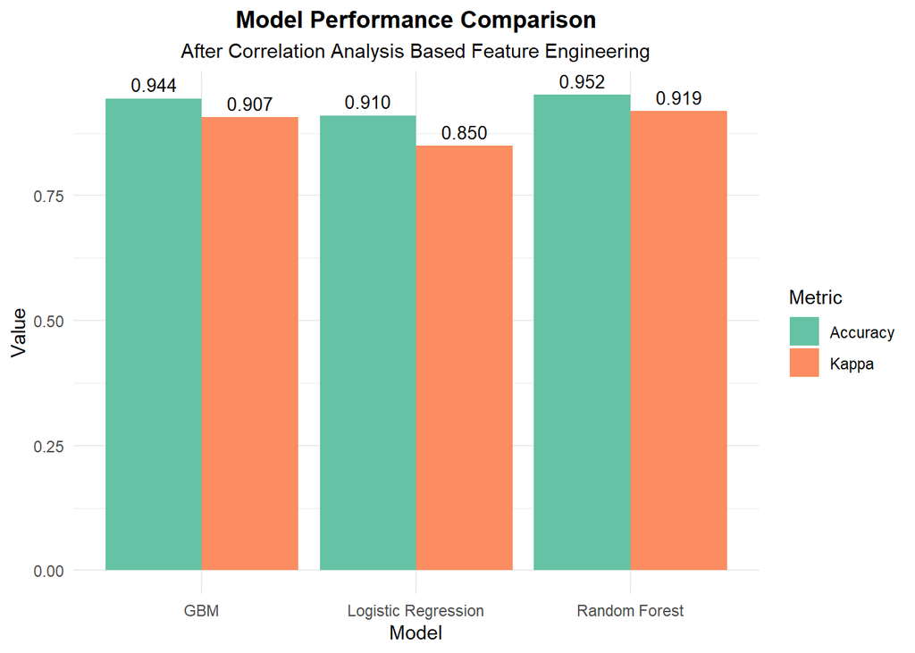

```r
performance_long <- performance_comparison %>%
  filter(!is.na(Accuracy) | !is.na(Kappa)) %>%
  tidyr::pivot_longer(cols = c(Accuracy, Kappa), names_to = "Metric", values_to = "Value") %>%
  dplyr::filter(!is.na(Value))

if (nrow(performance_long) > 0) {
  p_perf <- ggplot(performance_long, aes(x = Model, y = Value, fill = Metric)) +
    geom_bar(stat = "identity", position = position_dodge()) +
    geom_text(aes(label = sprintf("%.3f", Value)),
              position = position_dodge(width = 0.9), vjust = -0.5, size = 3.5) +
    scale_fill_brewer(palette = "Set2") +
    labs(
      title = "Model Performance Comparison",
      subtitle = "After Correlation Analysis Based Feature Engineering",
      x = "Model",
      y = "Value",
      fill = "Metric"
    ) +
    theme_minimal() +
    theme(plot.title = element_text(hjust = 0.5, face = "bold"),
          plot.subtitle = element_text(hjust = 0.5))

  print(p_perf)
  ggsave(file.path(PROJECT_DIR, "model_performance_comparison_final.png"),
         plot = p_perf, width = 12, height = 8)
}
```

## 16) Feature Importance - Model: rf_model from section 14. - Output: Top-20 features bar chart and CSVs (all and top-20). - Robustness: Handles multi-class varImp, adds short names for readability.

```r
## =========================================================
## 16) Feature Importance Analysis
## =========================================================
cat("\n", strrep("=", 60), "\n")
cat("FEATURE IMPORTANCE ANALYSIS\n")
```

```
## FEATURE IMPORTANCE ANALYSIS
```

```r
cat(strrep("=", 60), "\n")
```

```
##
## RANDOM FOREST - TOP 20 IMPORTANT VARIABLES:
##
## Top 20 Feature Importance:
##                                                                       Feature
## Total.Revenue_na_flag                                   Total.Revenue_na_flag
## Customer.Age..Months.                                   Customer.Age..Months.
## MRR                                                                       MRR
## MRR_na_flag                                                       MRR_na_flag
## Customer.Level.Enterprise                           Customer.Level.Enterprise
## Vertical.Finance                                             Vertical.Finance
## Subvertical.Other                                           Subvertical.Other
## response_delay_days                                       response_delay_days
## Region.Benelux                                                 Region.Benelux
## `Region.United Kingdom`                               `Region.United Kingdom`
## Total_Bug_Count                                               Total_Bug_Count
## Bug_Frequency                                                   Bug_Frequency
## Total.Revenue                                                   Total.Revenue
## Vertical.Retail                                               Vertical.Retail
## Region.Vietnam                                                 Region.Vietnam
## `Subvertical.Hotels and Accommodation` `Subvertical.Hotels and Accommodation`
## `Subvertical.Content Websites`                 `Subvertical.Content Websites`
## `Subvertical.Consumer Electronics`         `Subvertical.Consumer Electronics`
## `Subvertical.Animal Products`                   `Subvertical.Animal Products`
## Vertical.Other                                                 Vertical.Other
##                                         Overall
## Total.Revenue_na_flag                  62.24161
## Customer.Age..Months.                  36.24764
## MRR                                    24.70513
## MRR_na_flag                            24.24718
## Customer.Level.Enterprise              22.91803
## Vertical.Finance                       21.16824
## Subvertical.Other                      17.85653
## response_delay_days                    17.23357
## Region.Benelux                         16.53442
## `Region.United Kingdom`                16.22374
## Total_Bug_Count                        15.07815
## Bug_Frequency                          15.06691
## Total.Revenue                          14.80847
## Vertical.Retail                        14.71601
## Region.Vietnam                         14.45719
## `Subvertical.Hotels and Accommodation` 14.33466
## `Subvertical.Content Websites`         14.27100
## `Subvertical.Consumer Electronics`     14.20352
## `Subvertical.Animal Products`          14.01948
## Vertical.Other                         14.00927
```

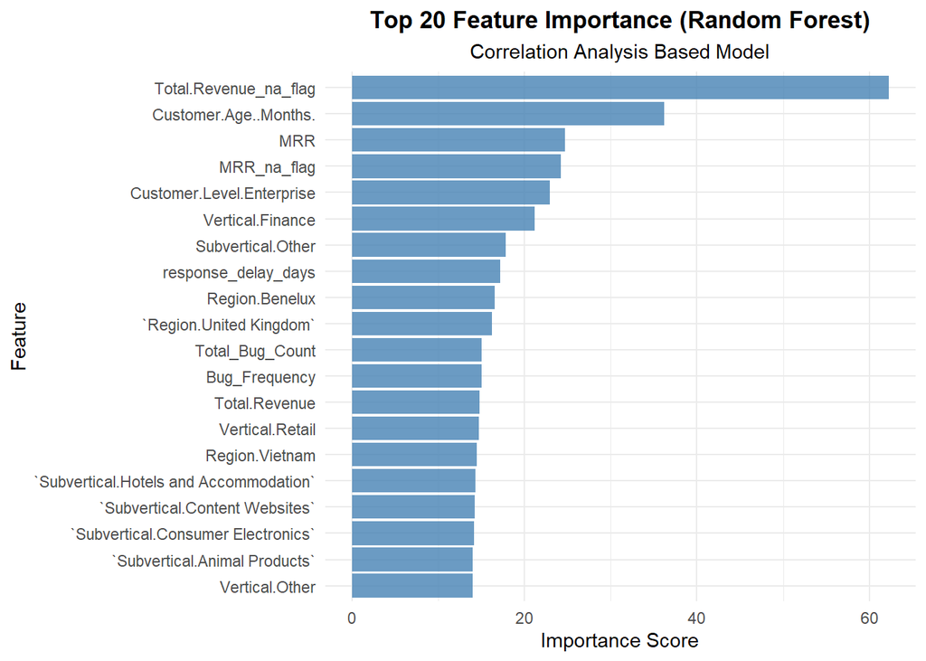

```
##
## Feature importance saved.
```

```r
if (exists("rf_model") && "finalModel" %in% names(rf_model)) {
  tryCatch({
    rf_importance <- varImp(rf_model, scale = TRUE)
    cat("\nRANDOM FOREST - TOP 20 IMPORTANT VARIABLES:\n")

    imp_df <- as.data.frame(rf_importance$importance)
    if (!"Feature" %in% colnames(imp_df)) imp_df$Feature <- rownames(imp_df)

    if (ncol(imp_df) > 2) {
      imp_values <- imp_df[, 1:(ncol(imp_df)-1)]
      imp_df$Overall <- rowMeans(imp_values, na.rm = TRUE)
    } else if (ncol(imp_df) == 2) {
      names(imp_df) <- c("Overall", "Feature")
    }

    imp_df <- imp_df[order(-imp_df$Overall), ]
    imp_df$Short_Name <- sapply(imp_df$Feature, function(x) {
      if (nchar(x) > 40) paste0(substr(x, 1, 37), "...") else x
    })

    top_20 <- head(imp_df, 20)
    cat("\nTop 20 Feature Importance:\n")
    print(top_20[, c("Feature", "Overall")])

    if (nrow(top_20) > 0) {
      p_imp <- ggplot(top_20, aes(x = reorder(Short_Name, Overall), y = Overall)) +
        geom_bar(stat = "identity", fill = "steelblue", alpha = 0.8) +
        coord_flip() +
        labs(
          title = "Top 20 Feature Importance (Random Forest)",
          subtitle = "Correlation Analysis Based Model",
          x = "Feature",
          y = "Importance Score"
        ) +
        theme_minimal() +
        theme(plot.title = element_text(hjust = 0.5, face = "bold"),
              plot.subtitle = element_text(hjust = 0.5))

      print(p_imp)
      ggsave(file.path(PROJECT_DIR, "feature_importance_top20.png"),
             plot = p_imp, width = 12, height = 8)

      write.csv(imp_df, file.path(PROJECT_DIR, "feature_importance_all.csv"), row.names = FALSE)
      write.csv(top_20, file.path(PROJECT_DIR, "feature_importance_top20.csv"), row.names = FALSE)
      cat("\nFeature importance saved.\n")
    }
  }, error = function(e) {
    cat("Feature importance could not be calculated:", e$message, "\n")
  })
} else {
  cat("rf_model not available; skipping feature importance.\n")
}
```

## 17) Save Objects (For Test Phase)

- **Purpose:** Persist all critical artifacts produced during the training phase so they can be reused consistently during the test phase.
- **Saved Objects:**
  - **Models:** Random Forest, Logistic Regression, GBM
  - **Preprocessing:** Dummy encoder object, categorical column list
  - **Datasets:** Training and modeling master tables
  - **Correlation Analysis:** Raw, post–feature engineering, and cleaned correlation outputs
  - **Performance Metrics:** Model performance comparison table
- **Output File:**
  - `train_models_final.RData`
- **Benefit:**
  - Ensures a **leak-free test pipeline** by reusing the exact same preprocessing and trained models.

```r
cat("\n", strrep("=", 60), "\n")
cat("SAVING OBJECTS...\n")
```

```
## SAVING OBJECTS...
```

```r
cat(strrep("=", 60), "\n")
save(
  # Model objects
  train_final,
  dummies,
  cat_cols,
  rf_model,
  log_model,
  gbm_model,

  # Original data
  master_train,
  master_model,

  # Correlation analysis results
  cor_matrix_raw,
  cor_matrix_final,
  cor_matrix_clean,
  high_corr_df_raw,
  high_corr_df_final,
  high_corr_df_clean,
  status_correlations_raw,
  status_correlations_final,
  status_correlations_clean,

  # Performance results
  performance_comparison,

  file = file.path(PROJECT_DIR, "train_models_final.RData")
)

cat("\nCREATED FILES:\n")
```

```
##
## CREATED FILES:
```

```r
cat("1. train_models_final.RData - Main model objects\n")
```

```
## 1. train_models_final.RData - Main model objects
```

```r
cat("2. correlation_raw_before_fe.png - Raw correlation heatmap\n")
```

```
## 2. correlation_raw_before_fe.png - Raw correlation heatmap
```

```r
cat("3. correlation_final_after_fe.png - Post-feature engineering heatmap\n")
```

```
## 3. correlation_final_after_fe.png - Post-feature engineering heatmap
```

```r
cat("4. correlation_clean_after_removal.png - Post-cleaning heatmap\n")
```

```
## 4. correlation_clean_after_removal.png - Post-cleaning heatmap
```

```r
cat("5. high_correlation_raw.csv - Raw high correlations\n")
```

```
## 5. high_correlation_raw.csv - Raw high correlations
```

```r
cat("6. high_correlation_final.csv - Post-feature engineering high correlations\n")
```

```
## 6. high_correlation_final.csv - Post-feature engineering high correlations
```

```r
cat("7. high_correlation_clean.csv - Post-cleaning high correlations\n")
```

```
## 7. high_correlation_clean.csv - Post-cleaning high correlations
```

```r
cat("8. status_correlation.png - Status correlation graph\n")
```

```
## 8. status_correlation.png - Status correlation graph
```

```r
cat("9. status_correlation_clean.png - Post-cleaning status correlation\n")
```

```
## 9. status_correlation_clean.png - Post-cleaning status correlation
```

```r
cat("10. new_features_correlation.png - New features correlation\n")
```

```
## 10. new_features_correlation.png - New features correlation
```

```r
cat("11. model_performance_comparison_final.png - Model performance\n")
```

```
## 11. model_performance_comparison_final.png - Model performance
```

```r
cat("12. feature_importance_top20.png - Feature importance\n")
```

```
## 12. feature_importance_top20.png - Feature importance
```

```r
cat("13. feature_importance_all.csv - All feature importance\n")
```

```
## 13. feature_importance_all.csv - All feature importance
```

```r
cat("14. feature_importance_top20.csv - Top 20 feature importance\n")
```

```
## 14. feature_importance_top20.csv - Top 20 feature importance
```

## 18) Summary Report

```r
cat("\n", strrep("=", 60), "\n")
cat("SUMMARY REPORT\n")
```

```
## SUMMARY REPORT
```

```r
cat(strrep("=", 60), "\n")
cat("\nDATA SUMMARY:\n")
```

```
##
## DATA SUMMARY:
```

```r
cat("Total Customers:", nrow(master_train), "\n")
```

```
## Total Customers: 2068
```

```r
cat("Train Set:", nrow(train_data), "\n")
```

```
## Train Set: 1655
```

```r
cat("Validation Set:", nrow(valid_data), "\n")
```

```
## Validation Set: 413
```

```r
cat("Total Features:", ncol(train_final) - 1, "\n")
```

```
## Total Features: 124
```

```r
cat("\nCORRELATION ANALYSIS COMPARISON:\n")
```

```
##
## CORRELATION ANALYSIS COMPARISON:
```

```r
cat("1. Before Feature Engineering:", ncol(numeric_vars_raw), "variables\n")
```

```
## 1. Before Feature Engineering: 12 variables
```

```r
cat("2. After Feature Engineering:", ncol(numeric_vars_final), "variables\n")
```

```
## 2. After Feature Engineering: 26 variables
```

```r
cat("3. After Cleaning:", ncol(numeric_vars_clean), "variables\n")
```

```
## 3. After Cleaning: 16 variables
```

```r
if (exists("high_corr_df_raw") && exists("high_corr_df_clean")) {
  cat("\nHIGH CORRELATION REDUCTION SUCCESS:\n")
  cat("   Initial:", nrow(high_corr_df_raw), "high correlation pairs\n")
  cat("   After Cleaning:", nrow(high_corr_df_clean), "high correlation pairs\n")

  if (nrow(high_corr_df_raw) > 0 && nrow(high_corr_df_clean) > 0) {
    reduction <- round(100 * (1 - nrow(high_corr_df_clean) / nrow(high_corr_df_raw)), 1)
    cat("   Reduction rate: %", reduction, "\n")
  }
}
```

```
##
## HIGH CORRELATION REDUCTION SUCCESS:
##    Initial: 3 high correlation pairs
##    After Cleaning: 0 high correlation pairs
```

```r
cat("\nNEW FEATURES:\n")
```

```
##
## NEW FEATURES:
```

```r
cat("1. Satisfaction_Composite - Satisfaction composite score\n")
```

```
## 1. Satisfaction_Composite - Satisfaction composite score
```

```r
cat("2. Support_Burden - Support burden\n")
```

```
## 2. Support_Burden - Support burden
```

```r
cat("3. Revenue_per_Month - Monthly revenue efficiency\n")
```

```
## 3. Revenue_per_Month - Monthly revenue efficiency
```

```r
cat("4. Bug_Frequency - Bug frequency\n")
```

```
## 4. Bug_Frequency - Bug frequency
```

```r
cat("5. Engagement_Ratio - Engagement ratio\n")
```

```
## 5. Engagement_Ratio - Engagement ratio
```

```r
cat("6. MRR_Ratio - MRR ratio\n")
```

```
## 6. MRR_Ratio - MRR ratio
```

```r
cat("\nMODEL RESULTS:\n")
```

```
##
## MODEL RESULTS:
```

```r
for (i in 1:nrow(performance_comparison)) {
  if (!is.na(performance_comparison$Accuracy[i])) {
    cat(sprintf("%-20s: Accuracy = %.3f, Kappa = %.3f\n",
                performance_comparison$Model[i],
                performance_comparison$Accuracy[i],
                performance_comparison$Kappa[i]))
  }
}
```

```
## Random Forest       : Accuracy = 0.952, Kappa = 0.919
## Logistic Regression : Accuracy = 0.910, Kappa = 0.850
## GBM                 : Accuracy = 0.944, Kappa = 0.907
```

```r
cat("\n", strrep("=", 60), "\n")
cat("TRAIN PHASE SUCCESSFULLY COMPLETED!\n")
```

```
## TRAIN PHASE SUCCESSFULLY COMPLETED!
```

```r
cat(strrep("=", 60), "\n")
cat("\nCompletion Time:", Sys.time(), "\n")
```

```
##
## Completion Time: 1766977309
```

```r
cat("Project Directory:", PROJECT_DIR, "\n")
```

```
## Project Directory: C:/Users/Bartu/Desktop/Customer_Status_Prediction
```

```r
cat("Ready to proceed to test phase!\n")
```

```
## Ready to proceed to test phase!
```

## 19) Advanced Train Visualizations (Different Techniques)

- **Purpose:** Go beyond standard plots to improve **interpretability and segment-level insights**.
- **Outputs:**
  1. **Lollipop Chart**
     - Visualizes the top predictors with the strongest correlation to customer status.
     - Highlights both magnitude and direction of influence.
  2. **Radar (Spider) Chart**
     - Compares normalized behavioral and financial profiles across customer status groups.
     - Useful for understanding multi-dimensional differences between segments.
- **Saved Files:**
  - `train_lollipop_influence.png`
  - `train_status_radar.png`
- **Benefit:**
  - Enhances **explainability** and stakeholder-friendly storytelling.

```r
cat("\n", strrep("=", 60), "\n")
```

```r
cat("GENERATING ADVANCED DIAGNOSTIC PLOTS\n")
```

```
## GENERATING ADVANCED DIAGNOSTIC PLOTS
```

```r
cat(strrep("=", 60), "\n")
```

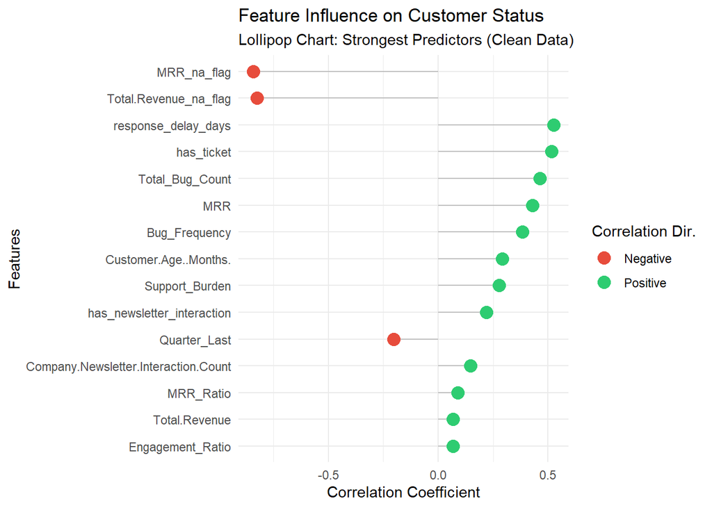

```r
# 19.1 Lollipop Chart: Top 15 Variables by Status Correlation
if (exists("status_correlations_clean")) {
  p_lollipop <- status_correlations_clean %>%
    head(15) %>%
    ggplot(aes(x = reorder(Variable, Abs_Correlation), y = Correlation_with_Status)) +
    geom_segment(aes(xend = Variable, yend = 0), color = "grey") +
    geom_point(aes(color = Correlation_with_Status > 0), size = 4) +
    scale_color_manual(values = c("TRUE" = "#2ecc71", "FALSE" = "#e74c3c"),
                       labels = c("Negative", "Positive"), name = "Correlation Dir.") +
    coord_flip() +
    labs(title = "Feature Influence on Customer Status",
         subtitle = "Lollipop Chart: Strongest Predictors (Clean Data)",
         x = "Features", y = "Correlation Coefficient") +
    theme_minimal()

  print(p_lollipop)
  ggsave(file.path(PROJECT_DIR, "train_lollipop_influence.png"), p_lollipop, width = 10, height = 7)
}
```

```r
# 19.2 Radar Chart (Spider Plot) - Status Characterization
cat("\nGenerating Status Profile Radar Analysis...\n")
```

```
##
## Generating Status Profile Radar Analysis...
```

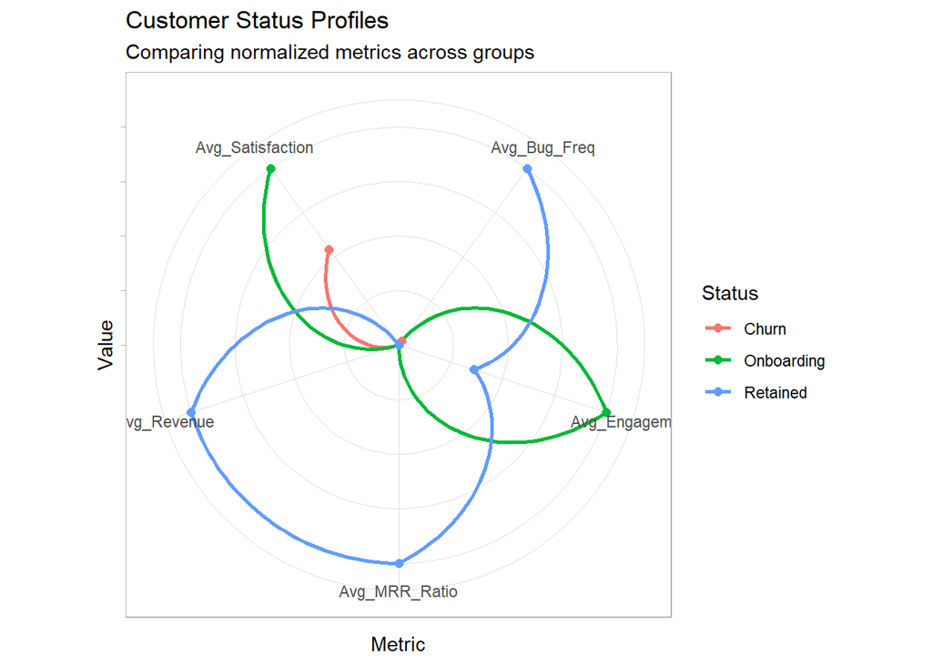

```r
radar_data <- master_train %>%
  group_by(Status) %>%
  summarise(
    Avg_Satisfaction = mean(Satisfaction_Composite, na.rm = TRUE),
    Avg_Bug_Freq = mean(Bug_Frequency, na.rm = TRUE),
    Avg_Engagement = mean(Engagement_Ratio, na.rm = TRUE),
    Avg_Revenue = mean(Revenue_per_Month, na.rm = TRUE),
    Avg_MRR_Ratio = mean(MRR_Ratio, na.rm = TRUE)
  ) %>%
  mutate(across(-Status, rescale)) # Normalize to 0-1 range

radar_long <- radar_data %>%
  pivot_longer(cols = -Status, names_to = "Metric", values_to = "Value")

p_radar <- ggplot(radar_long, aes(x = Metric, y = Value, group = Status, color = Status)) +
  geom_line(size = 1) +
  geom_point(size = 2) +
  coord_polar() +
  labs(title = "Customer Status Profiles",
       subtitle = "Comparing normalized metrics across groups") +
  theme_light() +
  theme(axis.text.y = element_blank())

print(p_radar)
```

```r
ggsave(file.path(PROJECT_DIR, "train_status_radar.png"), p_radar, width = 8, height = 8)
```

## 20) Multi-Model Confusion Matrix Visualization

```r
cat("\n", strrep("=", 60), "\n")
cat("GENERATING CONFUSION MATRICES FOR ALL MODELS\n")
```

```
## GENERATING CONFUSION MATRICES FOR ALL MODELS
```

```r
cat(strrep("=", 60), "\n")
```

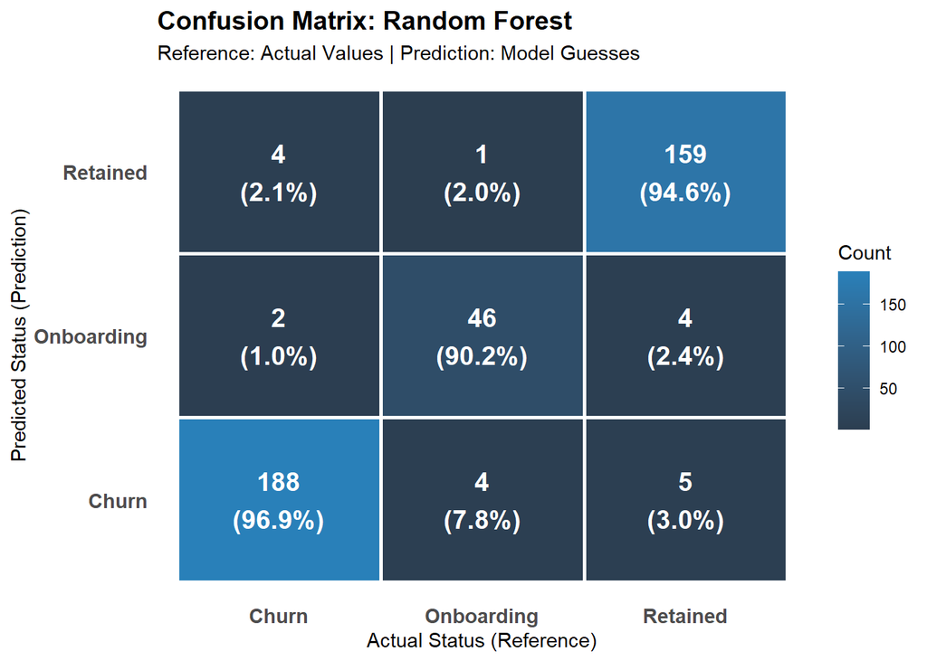

```
## Saved: confusion_matrix_random_forest.png
```

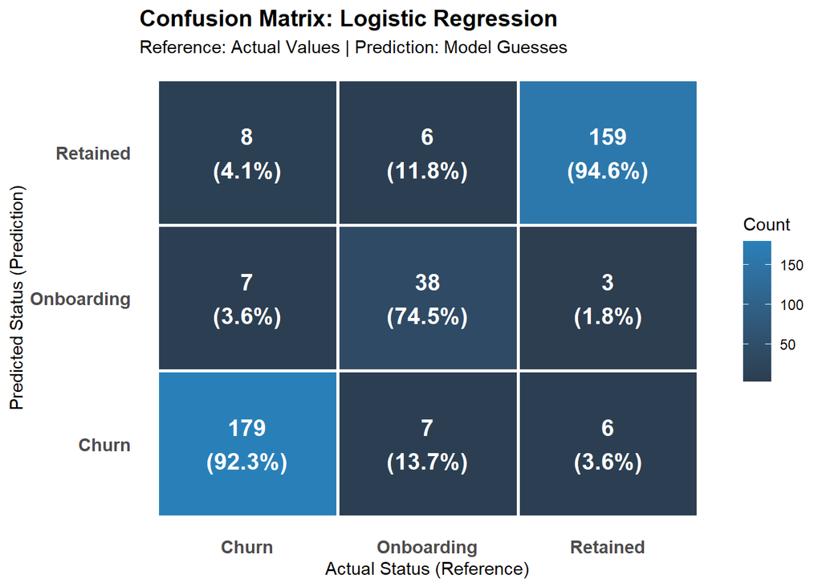

```
## Saved: confusion_matrix_logistic_regression.png
```

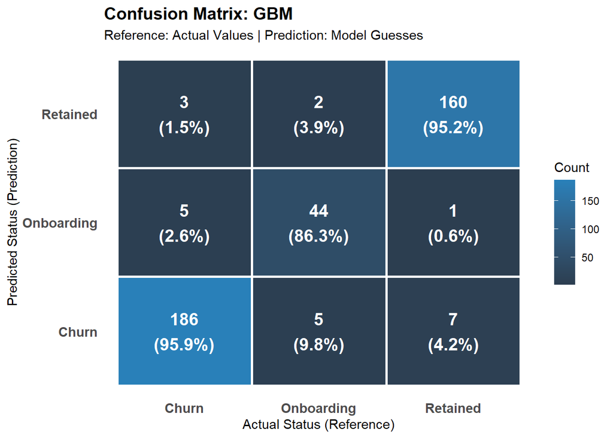

```
## Saved: confusion_matrix_gbm.png
```

```r
# Prepare model and CM list
cm_list <- list()
if (exists("cm_rf"))  cm_list[["Random_Forest"]] <- cm_rf
if (exists("cm_log")) cm_list[["Logistic_Regression"]] <- cm_log
if (exists("cm_gbm")) cm_list[["GBM"]] <- cm_gbm

if (length(cm_list) > 0) {
  for (model_name in names(cm_list)) {

    # 1. Prepare Data
    cm_obj <- cm_list[[model_name]]
    cm_df <- as.data.frame(cm_obj$table)

    # Calculate percentage values (for better analysis)
    cm_df <- cm_df %>%
      group_by(Reference) %>%
      mutate(Pct = Freq / sum(Freq) * 100) %>%
      ungroup()

    # 2. Visualization
    p_cm_model <- ggplot(cm_df, aes(x = Reference, y = Prediction, fill = Freq)) +
      geom_tile(color = "white", size = 1) +
      geom_text(aes(label = sprintf("%d\n(%.1f%%)", Freq, Pct)),
                color = "white", fontface = "bold", size = 5) +
      scale_fill_gradient(low = "#2c3e50", high = "#2980b9") +
      labs(
        title = paste("Confusion Matrix:", gsub("_", " ", model_name)),
        subtitle = "Reference: Actual Values | Prediction: Model Guesses",
        x = "Actual Status (Reference)",
        y = "Predicted Status (Prediction)",
        fill = "Count"
      ) +
      theme_minimal() +
      theme(
        plot.title = element_text(face = "bold", size = 14),
        axis.text = element_text(size = 11, face = "bold"),
        panel.grid = element_blank()
      )

    # 3. Print and Save
    print(p_cm_model)
    filename <- paste0("confusion_matrix_", tolower(model_name), ".png")
    ggsave(file.path(PROJECT_DIR, filename), p_cm_model, width = 8, height = 6)

    cat("Saved:", filename, "\n")
  }
} else {
  cat("No Confusion Matrix objects found (cm_rf, cm_log, or cm_gbm).\n")
}
```

## 21) Multi-Class ROC & AUC Analysis

- **Purpose:** Evaluate model discrimination power using **One-vs-Rest ROC and AUC metrics** for multi-class classification.
- **Process:**
  - Computes ROC curves separately for each class and model.
  - Aggregates AUC scores for comparative analysis.
- **Outputs:**
  - Faceted ROC curves by class
  - Bar charts summarizing AUC scores per model and class
- **Saved Files:**
  - `train_multi_roc_curves.png`
  - `train_auc_comparison.png`
- **Benefit:**
  - Provides a **threshold-independent performance assessment**.
  - Highlights which models perform best for specific customer segments.

```r
cat("\n", strrep("=", 60), "\n")
```

```r
cat("GENERATING ROC CURVES AND AUC SCORES\n")
```

```
## GENERATING ROC CURVES AND AUC SCORES
```

```r
cat(strrep("=", 60), "\n")
```

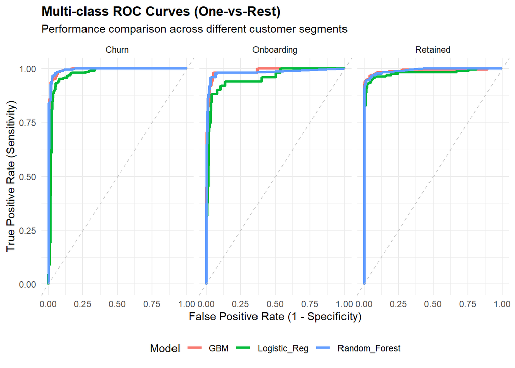

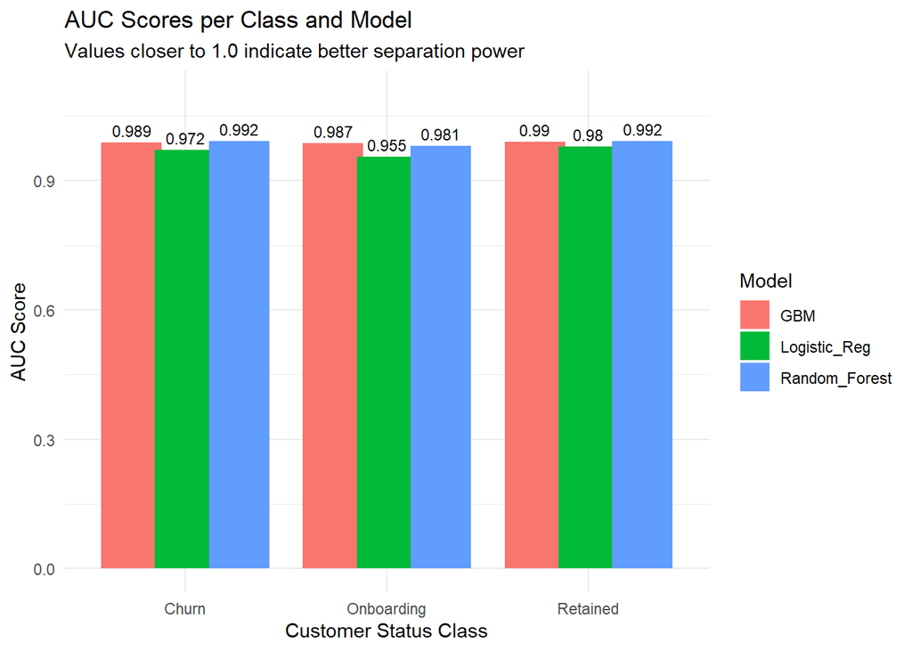

```
## ROC and AUC analysis completed. Check your folder for .png files.
```

```r
# Get prediction probabilities
prob_list <- list()
if (exists("rf_model"))  prob_list[["Random_Forest"]] <- predict(rf_model, newdata = valid_final, type = "prob")
if (exists("log_model")) prob_list[["Logistic_Reg"]] <- predict(log_model, newdata = valid_final, type = "probs")
if (exists("gbm_model")) prob_list[["GBM"]] <- predict(gbm_model, newdata = valid_final, type = "prob")

# List to store ROC data
roc_plot_data <- data.frame()

if (length(prob_list) > 0) {
  for (model_name in names(prob_list)) {
    probs <- prob_list[[model_name]]

    # Calculate ROC for each class (One-vs-Rest)
    classes <- levels(valid_final$Status)

    for (cl in classes) {
      # Convert actual values to binary (Selected class vs Others)
      binary_actual <- ifelse(valid_final$Status == cl, 1, 0)
      current_prob <- probs[, cl]

      roc_obj <- roc(binary_actual, current_prob, quiet = TRUE)

      # Add to plot data
      tmp_df <- data.frame(
        Specificity = roc_obj$specificities,
        Sensitivity = roc_obj$sensitivities,
        Model = model_name,
        Class = cl,
        AUC = as.numeric(roc_obj$auc)
      )
      roc_plot_data <- rbind(roc_plot_data, tmp_df)
    }
  }

  # 1. Separate ROC for Each Class (Facet Wrap)
  p_roc <- ggplot(roc_plot_data, aes(x = 1 - Specificity, y = Sensitivity, color = Model)) +
    geom_line(size = 1.2) +
    geom_abline(slope = 1, intercept = 0, linetype = "dashed", color = "grey") +
    facet_wrap(~Class) +
    labs(
      title = "Multi-class ROC Curves (One-vs-Rest)",
      subtitle = "Performance comparison across different customer segments",
      x = "False Positive Rate (1 - Specificity)",
      y = "True Positive Rate (Sensitivity)"
    ) +
    theme_minimal() +
    theme(legend.position = "bottom", plot.title = element_text(face = "bold"))

  print(p_roc)
  ggsave(file.path(PROJECT_DIR, "train_multi_roc_curves.png"), p_roc, width = 12, height = 7)

  # 2. AUC Score Summary Table Visualization
  auc_summary <- roc_plot_data %>%
    group_by(Model, Class) %>%
    summarise(AUC_Score = max(AUC), .groups = "drop")

  p_auc_bar <- ggplot(auc_summary, aes(x = Class, y = AUC_Score, fill = Model)) +
    geom_bar(stat = "identity", position = position_dodge(width = 0.8)) +
    geom_text(aes(label = round(AUC_Score, 3)),
              position = position_dodge(width = 0.8), vjust = -0.5, size = 3) +
    ylim(0, 1.1) +
    labs(
      title = "AUC Scores per Class and Model",
      subtitle = "Values closer to 1.0 indicate better separation power",
      x = "Customer Status Class",
      y = "AUC Score"
    ) +
    theme_minimal()

  print(p_auc_bar)
  ggsave(file.path(PROJECT_DIR, "train_auc_comparison.png"), p_auc_bar, width = 10, height = 6)

  cat("ROC and AUC analysis completed. Check your folder for .png files.\n")
} else {
  cat("Probabilities could not be retrieved for ROC analysis.\n")
}
```

```r
cat("\nAdvanced visualizations saved to your project directory.\n")
```

```
##
## Advanced visualizations saved to your project directory.
```

## 22) All Models Feature Importance Comparison

- **Purpose:** Compare feature importance patterns across different modeling techniques.
- **Methodology:**
  - **Random Forest:** Mean decrease–based importance
  - **GBM:** Model-derived relative importance
  - **Logistic Regression:** Absolute coefficient values (normalized) as an importance proxy
- **Visualization:**
  - Top 15 features per model displayed in faceted bar charts.
- **Saved File:**
  - `all_models_feature_importance.png`
- **Benefit:**
  - Reveals **model-specific drivers** and consensus predictors.
  - Supports interpretability and business-level feature validation.

```r
cat("\n", strrep("=", 60), "\n")
cat("GENERATING ALL-IN-ONE FEATURE IMPORTANCE COMPARISON\n")
```

```
## GENERATING ALL-IN-ONE FEATURE IMPORTANCE COMPARISON
```

```r
cat(strrep("=", 60), "\n")
```

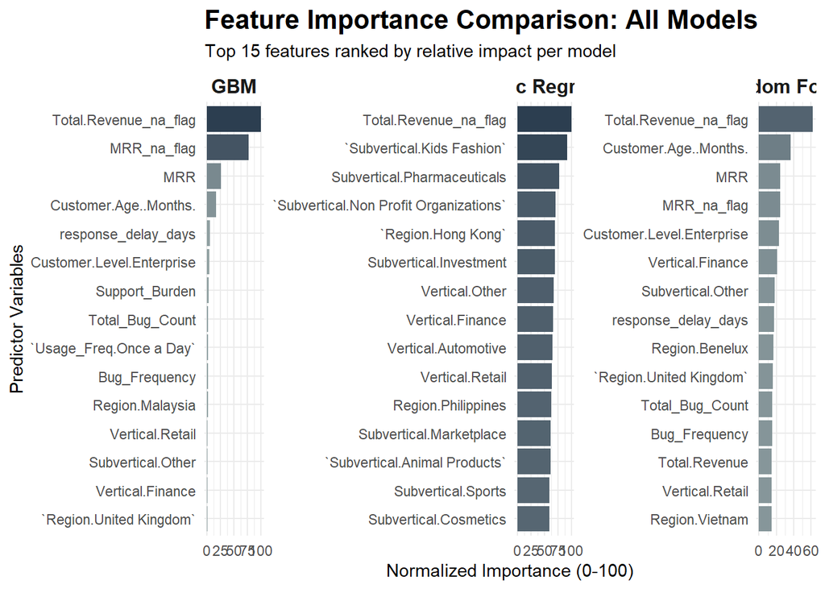

```
## Combined Feature Importance chart saved: all_models_feature_importance.png
```

```r
all_imp_data <- data.frame()

# 1. Random Forest Importance
if (exists("rf_model")) {
  rf_imp <- varImp(rf_model, scale = TRUE)$importance
  rf_df <- data.frame(
    Feature = rownames(rf_imp),
    Importance = rowMeans(rf_imp),
    Model = "Random Forest"
  )
  all_imp_data <- rbind(all_imp_data, rf_df)
}

# 2. GBM Importance
if (exists("gbm_model")) {
  gbm_imp <- varImp(gbm_model, scale = TRUE)$importance
  gbm_df <- data.frame(
    Feature = rownames(gbm_imp),
    Importance = gbm_imp$Overall,
    Model = "GBM"
  )
  all_imp_data <- rbind(all_imp_data, gbm_df)
}

# 3. Logistic Regression (Absolute Coefficients as Proxy for Importance)
if (exists("log_model") && !is.null(log_model)) {
  # In logistic regression, absolute coefficient values represent importance
  log_coefs <- abs(summary(log_model)$coefficients)
  # If multiple classes, take average of coefficients
  if (is.matrix(log_coefs)) {
    log_imp_vals <- colMeans(log_coefs)
  } else {
    log_imp_vals <- log_coefs
  }

  log_df <- data.frame(
    Feature = names(log_imp_vals),
    Importance = log_imp_vals,
    Model = "Logistic Regression"
  )
  # Normalize to 0-100 scale
  log_df$Importance <- (log_df$Importance / max(log_df$Importance)) * 100
  all_imp_data <- rbind(all_imp_data, log_df %>% filter(Feature != "(Intercept)"))
}

# 4. Visualization
if (nrow(all_imp_data) > 0) {
  # Select top 15 features for each model
  top_all_imp <- all_imp_data %>%
    group_by(Model) %>%
    arrange(desc(Importance)) %>%
    slice_head(n = 15) %>%
    ungroup()

  p_all_imp <- ggplot(top_all_imp, aes(x = reorder_within(Feature, Importance, Model),
                                       y = Importance, fill = Importance)) +
    geom_bar(stat = "identity") +
    scale_x_reordered() +
    scale_fill_gradient(low = "#95a5a6", high = "#2c3e50") +
    coord_flip() +
    facet_wrap(~Model, scales = "free") +
    labs(
      title = "Feature Importance Comparison: All Models",
      subtitle = "Top 15 features ranked by relative impact per model",
      x = "Predictor Variables",
      y = "Normalized Importance (0-100)"
    ) +
    theme_minimal() +
    theme(
      plot.title = element_text(face = "bold", size = 16),
      strip.text = element_text(face = "bold", size = 12),
      legend.position = "none"
    )

  print(p_all_imp)
  ggsave(file.path(PROJECT_DIR, "all_models_feature_importance.png"),
         plot = p_all_imp, width = 16, height = 9)

  cat("Combined Feature Importance chart saved: all_models_feature_importance.png\n")
}
```